# Livestock diet items

Lolita Muller

m.lolita@cgiar.org

Peter Steward

p.steward@cgiar.org

Namita Joshi

n.joshi@cgiar.org

Todd Rosenstock

t.rosenstock@cgiar.org

2025-02-19

## Introduction

### Objectives

This analysis implements a comprehensive and automated workflow to **estimate enteric methane (CH₄) emissions from livestock** using the **IPCC Tier 2 methodology**. It integrates and harmonizes livestock diet data, nutritional composition, feed intake, and supplementary sources (e.g., Feedipedia) to enable robust and reproducible emissions estimation across diverse studies.

## Methods

This section outlines the data processing and estimation steps used to calculate gross energy (GE) and feed intake for livestock diet ingredients, which are essential inputs for estimating enteric methane (CH₄) emissions using the IPCC Tier 2 methodology.

### Data Sources

- **ERA Livestock Metadata**: Harmonized records of diets, ingredients, and feeding trials for ruminants across Africa.
- **ERA Camel Metadata**: Similar structured data for camelid systems.
- **Feedipedia**: A curated nutritional database used to supplement missing information (gross energy, crude protein, ether extract, ash, digestibility).
- **ERA Master Sheet (AOM)**: Maps extracted diet ingredients to Feedipedia entries for integration.

### Gross Energy (GE) and Feed Intake Calculation Workflow

#### 1. Harmonization of Units

Ingredient amounts and feed intake values were standardized to consistent units: - **Weight**: Converted to grams (g) or kilograms (kg) - **Time**: Normalized to daily intake (e.g., g/day) - **Animals**: Adjusted from replicate-level to individual-level when group sizes were known

#### 2. Linking Ingredients to Feedipedia

Each diet ingredient was mapped to a Feedipedia code using the ERA master sheet. This linkage enabled the retrieval of: - Nutritional values (GE, CP, EE, Ash) - Digestibility coefficients (e.g., DE)

#### 3. Gross Energy (GE) Sources and Inference

All values were harmonized to MJ/kg.

#### 4. Feed Intake Estimation

Feed intake was taken from two sources:

- **Direct feed intake records** from the metadata (converted to kg/day/animal), adjusted based on units and animal body weight where needed (e.g., % body weight, g/kg BW).
- **Ingredient-level diet amounts**, when feed intake data was not available or missing. Intake was inferred by summing ingredient contributions.

When both sources were available, **direct feed intake values were prioritized** for accuracy.

#### 5. Proportion of Ingredients in the Diet

When complete diet formulations were available, the relative contribution (%) of each ingredient to the full diet was calculated. These were used to reconstruct diet-level GE values when needed.

#### 6. Data Imputation and Quality Checks

This methodology enables consistent and robust estimation of GE and intake for each ingredient, which supports CH₄ emissions estimation even in data-limited contexts.

## 1) Set up

Download the packages and download the data from the s3 bucket.

```r
# Install and load 'pacman' package manager if not already installed

library(ERAg)
library(stringr)
library(knitr)
library(dplyr)
library(DT)
library(readxl)
library(tidyr)
library(arrow)
library(ggplot2)
library(data.table)
library(purrr)

# Set up connection to S3 bucket
s3 <- s3fs::S3FileSystem$new(anonymous = TRUE)
era_s3 <- "s3://digital-atlas/era"

# List the files in the s3 bucket
files <- s3$dir_ls(file.path(era_s3,"data"))

# Identify the latest skinny_cow_2022-YYYY-MM-DD.RData file
files <- tail(grep(".RData", grep("skinny_cow_2022", files, value=TRUE), value=TRUE), 1)

# Download to local if not already present
save_path <- file.path(getwd(), basename(files))
if(!file.exists(save_path)){
  s3$file_download(files, save_path, overwrite = TRUE)
}

# Load the data
livestock_metadata <- miceadds::load.Rdata2(file=basename(save_path), path=dirname(save_path))

# #total number of studies
# total_studies<- length(unique(livestock_metadata$Animals.Diet$B.Code))
# total_ingredients<- length(unique(livestock_metadata$Animals.Diet$D.Item))
# total_diets<- length(unique(livestock_metadata$Animals.Diet$A.Level.Name))
#
```

```r
# Set up connection to S3 bucket
s3 <- s3fs::S3FileSystem$new(anonymous = TRUE)
era_s3 <- "s3://digital-atlas/era"

# List the files in the s3 bucket
files <- s3$dir_ls(file.path(era_s3,"data"))

# Identify the latest skinny_cow_2022-YYYY-MM-DD.RData file
files <- tail(grep(".RData", grep("courageous_camel_2024-draft-2025-03-27.1", files, value=TRUE), value=TRUE), 1)

# Download to local if not already present
save_path <- file.path(getwd(), basename(files))
if(!file.exists(save_path)){
  s3$file_download(files, save_path, overwrite = TRUE)
}

# Load the data
camel <- miceadds::load.Rdata2(file=basename(save_path), path=dirname(save_path))
```

```r
#merge camel and livestock
# Define column lists (as character vectors)
diet_cols <- c("B.Code", "A.Level.Name", "D.Item", "D.Type", "D.Amount",
               "D.Unit.Amount", "D.Unit.Time", "D.Unit.Animals", "DC.Is.Dry",
               "D.Ad.lib", "D.Is.Group")

mt_cols <- c("B.Code", "A.Level.Name", "T.Animals")

comp_cols <- c("B.Code", "D.Item", "is_entire_diet", "DC.Variable",
               "DC.Value", "DC.Unit")

digest_cols <- c("B.Code", "D.Item", "is_entire_diet", "DD.Variable",
                 "DD.Value", "DD.Unit")

data_cols <- c("B.Code", "A.Level.Name", "ED.Intake.Item", "ED.Intake.Item.Raw",
               "ED.Mean.T", "ED.Error","Out.Subind", "Out.Unit", "Out.WG.Start", "Out.WG.Unit")

prod_cols <- c("B.Code", "P.Product")

# Extract livestock tables and add Source column
diet_livestock   <- livestock_metadata$Animals.Diet[, ..diet_cols][, Source := "livestock"]
mt_livestock     <- livestock_metadata$MT.Out[, ..mt_cols][, Source := "livestock"]
comp_livestock   <- livestock_metadata$Animals.Diet.Comp[, ..comp_cols][, Source := "livestock"]
digest_livestock <- livestock_metadata$Animals.Diet.Digest[, ..digest_cols][, Source := "livestock"]
data_livestock   <- livestock_metadata$Data.Out[, ..data_cols][, Source := "livestock"]
prod_livestock   <- livestock_metadata$Prod.Out[, ..prod_cols][, Source := "livestock"]

# Extract camel tables and rename columns to match livestock structure
diet_camel <- camel$Animal.Diet[, ..diet_cols][, Source := "camel"]

# Construct MT.Out for camel: get A.Level.Name and T.Animals from Herd
mt_camel <- camel$Herd.Out[, .(
  B.Code, T.Animals = Herd.N
)][, Source := "camel"]

# Rename DN.* to DC.* in camel Diet.Comp
comp_camel <- camel$Animal.Diet.Comp[, .(
  B.Code, D.Item, is_entire_diet,
  DC.Variable = DN.Variable,
  DC.Value = DN.Value,
  DC.Unit = DN.Unit
)][, Source := "camel"]

# Rename DD.* and add digestibility source
digest_camel <- camel$Animal.Diet.Digest[, .(
  B.Code, D.Item, is_entire_diet,
  DD.Variable = DD.Variable,
  DD.Value = DD.Value,
  DD.Unit = DD.Unit
)][, Source := "camel"]

# Join Data.Out from camel with Herd to get weight info
herd_weight <- camel$Herd.Out[, .(
  B.Code, A.Level.Name = Herd.Level.Name,
  Out.WG.Start = Herd.Start.Weight,
  Out.WG.Unit = Herd.Start.Weight.Unit
)]

data_camel <- camel$Data.Out[
  , .(B.Code, ED.Intake.Item,
      ED.Intake.Item.Raw = ED.Intake.Item,
      A.Level.Name= T.Name,  # Temporarily keep this as-is for now
      ED.Mean.T, ED.Error, Out.Unit,Out.Subind)
][
  herd_weight,
  on = .(B.Code),
  `:=`(P.Product = i.A.Level.Name,
       Out.WG.Start = i.Out.WG.Start,
       Out.WG.Unit = i.Out.WG.Unit)
][
  , .(B.Code, A.Level.Name, ED.Intake.Item, ED.Intake.Item.Raw,
      ED.Mean.T, ED.Error, Out.Unit,Out.Subind, Out.WG.Start, Out.WG.Unit)
][, Source := "camel"]


# Extract product info from Herd table in camel
prod_camel <- camel$Herd.Out[, .(B.Code, P.Product = V.Product)][, Source := "camel"]

# Merge camel and livestock datasets
diet_all   <- rbindlist(list(diet_livestock, diet_camel), fill = TRUE)
mt_all     <- rbindlist(list(mt_livestock, mt_camel), fill = TRUE)
comp_all   <- rbindlist(list(comp_livestock, comp_camel), fill = TRUE)
digest_all <- rbindlist(list(digest_livestock, digest_camel), fill = TRUE)
data_all   <- rbindlist(list(data_livestock, data_camel), fill = TRUE)
prod_all   <- rbindlist(list(prod_livestock, prod_camel), fill = TRUE)

# Final merged metadata list
merged_metadata <- list(
  Animals.Diet        = diet_all,
  MT.Out              = mt_all,
  Animals.Diet.Comp   = comp_all,
  Animals.Diet.Digest = digest_all,
  Data.Out            = data_all,
  Prod.Out            = prod_all
)

# total_studies<- length(unique(merged_metadata$Animals.Diet$B.Code))
# total_ingredients<- length(unique(merged_metadata$Animals.Diet$D.Item))
# total_diets<- length(unique(merged_metadata$Animals.Diet$A.Level.Name))
```

```r
# Clean up intermediate objects
rm(
  diet_cols, mt_cols, comp_cols, digest_cols, data_cols, prod_cols,
  diet_livestock, mt_livestock, comp_livestock, digest_livestock, data_livestock, prod_livestock,
  diet_camel, mt_camel, comp_camel, digest_camel, data_camel, prod_camel, herd_weight,comp_all,data_all,diet_all,digest_all,mt_all,prod_all,livestock_metadata,camel)

# (Optional) Run gc() to free memory
gc()
```

```
##           used  (Mb) gc trigger  (Mb) max used  (Mb)
## Ncells 3604723 192.6    7279998 388.8  4582582 244.8
## Vcells 6705048  51.2   15863772 121.1 11655676  89.0
```

```r
## keep ingredient that appear twice with different units only once

# Define your unit preferences
preferred_units <- c("g", "kg")
preferred_time <- "day"
preferred_animals <- "individual"

# Prioritize and deduplicate
merged_metadata$Animals.Diet <- merged_metadata$Animals.Diet %>%
  # Add a priority score to sort by best rows
  mutate(
    priority = case_when(
      D.Unit.Amount %in% preferred_units &
        D.Unit.Time == preferred_time &
        D.Unit.Animals == preferred_animals ~ 1,
      TRUE ~ 2  # lower priority
    )
  ) %>%
  group_by(B.Code, A.Level.Name, D.Item) %>%
  slice_min(order_by = priority, with_ties = FALSE) %>%
  ungroup() %>%
  select(-priority)  # optional: drop helper column
```

```r
# Define species of interest
species_list <- c("Cattle", "Sheep", "Goat")

# Initialize result containers
species_summary <- list()
bcode_table <- list()

# Loop over each species
for (species in species_list) {

  # All B.Codes for this species
  species_bcodes <- merged_metadata$Prod.Out %>%
    filter(P.Product == species) %>%
    pull(B.Code) %>%
    unique()

  # Feed intake B.Codes
  feed_data <- merged_metadata$Data.Out %>%
    filter(B.Code %in% species_bcodes, !is.na(ED.Mean.T)) %>%
    filter(Out.Subind=="Feed Intake")%>%
    select(B.Code, D.Item = ED.Intake.Item)

  feed_bcodes <- unique(feed_data$B.Code)

  # GE B.Codes
  ge_data <- merged_metadata$Animals.Diet.Comp %>%
    filter(B.Code %in% species_bcodes, DC.Variable == "GE", !is.na(DC.Value)) %>%
    select(B.Code, D.Item)

  ge_bcodes <- unique(ge_data$B.Code)

  # Matched B.Codes (join on both B.Code and D.Item)
  matched_bcodes <- inner_join(feed_data, ge_data, by = c("B.Code", "D.Item")) %>%
    pull(B.Code) %>%
    unique()

  # Store species-level summary
  species_summary[[species]] <- tibble(
    Species = species,
    Total_BCodes = length(species_bcodes),
    With_FEED = length(feed_bcodes),
    With_GE = length(ge_bcodes),
    With_BOTH = length(matched_bcodes)
  )

  # Store long-format bcode list
  bcode_table[[species]] <- tibble(
    B.Code = c(species_bcodes, feed_bcodes, ge_bcodes, matched_bcodes),
    Category = rep(c("All", "With_FEED", "With_GE", "With_BOTH"),
                   times = c(length(species_bcodes), length(feed_bcodes), length(ge_bcodes), length(matched_bcodes))),
    Species = species
  ) %>% distinct()
}

# Bind results
species_summary_df <- bind_rows(species_summary)
bcode_table_df <- bind_rows(bcode_table)
```

## 2) Harmonize units of ingredient amounts

```r
# diet ingredients: breakdown of all ingredients within each diet
ingredients <- merged_metadata$Animals.Diet %>%
  dplyr::select(
    B.Code,
    A.Level.Name,
    D.Item,
    D.Type,
    D.Amount,
    D.Unit.Amount,
    D.Unit.Time,
    D.Unit.Animals,
    DC.Is.Dry,
    D.Ad.lib,
    D.Is.Group
  ) %>%
  mutate(D.Amount = as.numeric(D.Amount))

# Function to harmonize diet ingredient units
harmonize_units <- function(df) {
  df %>%
    mutate(
      # Record original units (optional, for debugging/traceability)
      Units = paste(D.Unit.Amount, D.Unit.Time, D.Unit.Animals, sep=";"),

      # Harmonize weight and volume units to a consistent base
      D.Amount = case_when(
        D.Unit.Amount %in% c("kg", "mg", "g/100g", "l", "kg/t", "g/300l",
                             "mg/kg", "kg/100kg", "kg/kg metabolic weight",
                             "kg/100kg body weight", "g/kg metabolic weight (0.75)",
                             "g/L") ~ {
          case_when(
            D.Unit.Amount == "kg" ~ D.Amount * 1000,                      # kg -> g
            D.Unit.Amount == "mg" ~ D.Amount / 1000,                     # mg -> g
            D.Unit.Amount == "g/100g" ~ D.Amount * 10,                   # g/100g -> g/kg
            D.Unit.Amount == "l" ~ D.Amount * 1000,                      # l -> ml (assumed g ~ ml in water)
            D.Unit.Amount == "kg/t" ~ D.Amount * 1000,                   # kg/t -> g/kg
            D.Unit.Amount == "g/300l" ~ D.Amount / 300,                  # g/300l -> g/L
            D.Unit.Amount == "mg/kg" ~ D.Amount / 1000,                  # mg/kg -> g/kg
            D.Unit.Amount == "kg/100kg body weight" ~ D.Amount * 10,     # -> g/kg body weight
            D.Unit.Amount == "kg/kg metabolic weight" ~ D.Amount * 1000, # -> g/kg metabolic weight
            TRUE ~ D.Amount
          )
        },
        TRUE ~ D.Amount
      ),

      # Update D.Unit.Amount to reflect new base
      D.Unit.Amount = case_when(
        D.Unit.Amount == "kg"  ~ "g",
        D.Unit.Amount == "mg"  ~ "g",
        D.Unit.Amount == "g/100g" ~ "g/kg",
        D.Unit.Amount == "l"  ~ "ml",
        D.Unit.Amount == "kg/t" ~ "g/kg",
        D.Unit.Amount == "g/300l" ~ "g/L",
        D.Unit.Amount == "mg/kg" ~ "g/kg",
        D.Unit.Amount == "kg/100kg body weight" ~ "g/kg body weight",
        D.Unit.Amount == "kg/kg metabolic weight" ~ "g/kg metabolic weight",
        D.Unit.Amount == "g/kg metabolic weight (0.75)" ~ "g/kg metabolic weight",
        D.Unit.Amount == "g/L" ~ "g/L",
        TRUE ~ D.Unit.Amount
      ),

      # Harmonize time units to day
      D.Amount = case_when(
        D.Unit.Time == "week" ~ D.Amount / 7,
        D.Unit.Time == "month" ~ D.Amount / 30,
        D.Unit.Time == "2 weeks" ~ D.Amount / 14,
        D.Unit.Time == "4 days interval" ~ D.Amount / 4,
        D.Unit.Time == "2x/day" ~ D.Amount * 2,
        TRUE ~ D.Amount
      ),
       D.Unit.Time = ifelse(!is.na(D.Unit.Time), "day", D.Unit.Time)
    ) %>%
    # NEW: If D.Amount is NA, set unit fields to NA as well
    mutate(
      D.Unit.Amount   = ifelse(is.na(D.Amount), NA_character_, D.Unit.Amount),
      D.Unit.Time     = ifelse(is.na(D.Amount), NA_character_, D.Unit.Time),
      D.Unit.Animals  = ifelse(is.na(D.Amount), NA_character_, D.Unit.Animals)
    )
}

# Apply the harmonization
ingredients <- harmonize_units(ingredients)

# Load replicate info to adjust for "all animals in replicate"
reps <- merged_metadata$MT.Out %>%
  mutate(T.Animals = as.numeric(T.Animals)) %>%
  distinct(B.Code, A.Level.Name, .keep_all = TRUE)

ingredients <- ingredients %>%
  left_join(reps %>% dplyr::select(B.Code, A.Level.Name, T.Animals), by=c("B.Code","A.Level.Name")) %>%
  mutate(
    D.Amount = case_when(
      D.Unit.Animals == "all animals in replicate" & !is.na(T.Animals) ~ D.Amount / T.Animals,
      TRUE ~ D.Amount
    ),
    D.Unit.Animals = ifelse(D.Unit.Animals == "all animals in replicate", "individual", D.Unit.Animals)
  )

# Refresh 'Units' column after these adjustments (optional)
ingredients <- ingredients %>%
  mutate(Units = paste(D.Unit.Amount, D.Unit.Time, D.Unit.Animals, sep=";"))
```

```r
# Define a list of acceptable units
acceptable_units <- c("g/kg","g","%","ml","L","kg","g/L",
                      "g/kg metabolic weight (0.75)","% Diet","kg/kg metabolic weight",
                      "g/kg body weight","ml/kg","% Body Mass","% Concentrate",
                      "kg/100kg body weight")

# Filter rows to keep only acceptable units
ingredients_harmonized <- ingredients %>%
  filter(D.Unit.Amount %in% acceptable_units | is.na(D.Unit.Amount)) %>%
  mutate(D.Item = ifelse(is.na(D.Item), "Unspecified", D.Item))

#tracking paper loss because of harmnozied units
total_studies_harmonized<- length(unique(ingredients_harmonized$B.Code))
total_ingredients_harmonized<- length(unique(ingredients_harmonized$D.Item))
total_diets_harmonized<- length(unique(ingredients_harmonized$A.Level.Name))
```

## 3) Link ingredients to feedipedia

Feedipedia is an online database that provides comprehensive information on feed ingredients used in livestock nutrition. It aggregates data on the nutritional composition, digestibility, and other relevant properties of various feeds.We will use it to infer data when info is missing from our data extraction.

```r
## download data from feedapedia (generated with the "feedapedia scrapping script available on github)

# Use the raw URL of the file on GitHub
url <- "https://github.com/ERAgriculture/ERL/raw/main/downloaded_data/feedipedia.parquet"

# Create a temporary file location with a .parquet extension
temp_file <- tempfile(fileext = ".parquet")

# Download the file in binary mode
download.file(url, destfile = temp_file, mode = "wb")

# Read the Parquet file
feedipedia <- read_parquet(temp_file)

## download AOM with the correspondance between feedipedia codes and diet items

# Define the raw URL for the Excel file
url <- "https://raw.githubusercontent.com/peetmate/era_codes/main/era_master_sheet.xlsx"

# Download the file to a temporary location
temp_file <- tempfile(fileext = ".xlsx")
download.file(url, destfile = temp_file, mode = "wb")

# Read only the sheet called "AOM"
mastersheet <- read_excel(temp_file, sheet = "AOM") %>%
  filter(L5=="Feed Ingredient")

mastersheet$Feedipedia <- as.numeric(sub(".*node/", "", mastersheet$Feedipedia))
```

add nutrition and digestibility from feedipedia

```r
# --- A) Add Feedipedia node from mastersheet into Comp and Digest tables
add_feedipedia_node <- function(df, mastersheet) {
  df %>%
    left_join(
      mastersheet %>% select(Edge_Value, Feedipedia),
      by = c("D.Item" = "Edge_Value")
    ) %>%
    distinct()
}

merged_metadata$Animals.Diet.Comp   <- add_feedipedia_node(merged_metadata$Animals.Diet.Comp, mastersheet)
merged_metadata$Animals.Diet.Digest <- add_feedipedia_node(merged_metadata$Animals.Diet.Digest, mastersheet)

# --- B) Standardize Feedipedia variables and assign categories
digestibility_keywords <- c(
  "digestibility", "degradability", "energy digestibility",
  "DE", "ME", "NE", "AMEn", "OM digestibility", "DM digestibility",
  "ruminants", "rabbit", "pig", "poultry", "horse", "salmonids", "hydrolysis"
)

feedipedia <- feedipedia %>%
  mutate(
    Variable = case_when(
      tolower(Variable) == "gross energy" ~ "GE",
      tolower(Variable) == "crude protein" ~ "CP",
      tolower(Variable) == "ether extract" ~ "EE",
      tolower(Variable) == "ash" ~ "Ash",
      TRUE ~ Variable
    ),
    category = case_when(
      Variable %in% c("GE", "CP", "EE", "Ash") ~ "nutrition",
      str_detect(Variable, regex(paste(digestibility_keywords, collapse = "|"), ignore_case = TRUE)) ~ "digestibility",
      TRUE ~ "nutrition"
    ),
    feedipedia_node = as.numeric(feedipedia_node)
  )

# --- C) Ensure source columns exist
if (!"nutrition_source" %in% names(merged_metadata$Animals.Diet.Comp)) {
  merged_metadata$Animals.Diet.Comp$nutrition_source <- NA_character_
}
if (!"digestibility_source" %in% names(merged_metadata$Animals.Diet.Digest)) {
  merged_metadata$Animals.Diet.Digest$digestibility_source <- NA_character_
}

# --- D) Nutrition variables: GE, CP, EE, Ash
nutrition_vars <- c("GE", "CP", "EE", "Ash")

feedipedia_nutrition <- feedipedia %>%
  filter(Variable %in% nutrition_vars) %>%
  group_by(feedipedia_node, Variable, Unit) %>%
  summarise(Value = mean(Avg, na.rm = TRUE), .groups = "drop") %>%
  rename(DC.Variable = Variable, DC.Value.feedipedia = Value)

# --- E) Join nutrition into Animals.Diet.Comp
merged_metadata$Animals.Diet.Comp <- merged_metadata$Animals.Diet.Comp %>%
  mutate(Feedipedia = as.numeric(Feedipedia)) %>%
  left_join(feedipedia_nutrition, by = c("Feedipedia" = "feedipedia_node", "DC.Variable")) %>%
  mutate(
    value_missing = is.na(DC.Value),
    DC.Value = coalesce(DC.Value, DC.Value.feedipedia),
    DC.Unit  = if_else(value_missing & !is.na(DC.Value.feedipedia), Unit, DC.Unit),
    nutrition_source = if_else(value_missing & !is.na(DC.Value.feedipedia), "feedipedia", nutrition_source)
  ) %>%
  select(-DC.Value.feedipedia, -Unit, -value_missing)

# --- F) Digestibility: Energy digestibility, ruminants → DE
feedipedia_digestibility <- feedipedia %>%
  filter(tolower(Variable) == "energy digestibility, ruminants") %>%
  group_by(feedipedia_node, Variable, Unit) %>%
  summarise(Value = mean(Avg, na.rm = TRUE), .groups = "drop") %>%
  mutate(DD.Variable = "DE", feedipedia_node = as.numeric(feedipedia_node)) %>%
  rename(DD.Value.feedipedia = Value)

merged_metadata$Animals.Diet.Digest <- merged_metadata$Animals.Diet.Digest %>%
  mutate(Feedipedia = as.numeric(Feedipedia)) %>%
  left_join(feedipedia_digestibility, by = c("Feedipedia" = "feedipedia_node", "DD.Variable")) %>%
  mutate(
    value_missing = is.na(DD.Value),
    DD.Value = coalesce(DD.Value, DD.Value.feedipedia),
    DD.Unit  = if_else(value_missing & !is.na(DD.Value.feedipedia), Unit, DD.Unit),
    digestibility_source = if_else(value_missing & !is.na(DD.Value.feedipedia), "feedipedia", digestibility_source)
  ) %>%
  select(-DD.Value.feedipedia, -Unit, -value_missing)
```

```r
# ✅ Count how many papers had GE filled by Feedipedia, and how many of those are Cattle / Sheep / Goat

# Step 1: Filter for Feedipedia-filled GE entries
ge_filled_by_feedipedia <- merged_metadata$Animals.Diet.Comp %>%
  filter(DC.Variable == "GE", nutrition_source == "feedipedia") %>%
  distinct(B.Code)

# Step 2: Total number of studies
n_ge_feedipedia <- nrow(ge_filled_by_feedipedia)

# Step 3: Add species info and filter to ruminants
ge_species_feedipedia <- ge_filled_by_feedipedia %>%
  left_join(merged_metadata$`Prod.Out` %>% select(B.Code, P.Product), by = "B.Code") %>%
  filter(P.Product %in% c("Cattle", "Sheep", "Goat")) %>%
  distinct(B.Code, P.Product)

# Step 4: Count per species
ge_species_counts <- ge_species_feedipedia %>%
  count(P.Product, name = "Papers_with_GE_from_Feedipedia")

# Display summary
cat("📌 Total papers with GE filled from Feedipedia:", n_ge_feedipedia, "\n")
```

```
## 📌 Total papers with GE filled from Feedipedia: 112
```

```r
cat("📌 Of those, species breakdown:\n")
```

```
## 📌 Of those, species breakdown:
```

```r
print(ge_species_counts)
```

```
##    P.Product Papers_with_GE_from_Feedipedia
##       <char>                          <int>
## 1:    Cattle                             24
## 2:      Goat                             28
## 3:     Sheep                             44
```

```r
# Define species of interest
species_list <- c("Cattle", "Sheep", "Goat")

# Initialize result containers
species_summary <- list()
bcode_table <- list()

# Loop over each species
for (species in species_list) {

  # All B.Codes for this species
  species_bcodes <- merged_metadata$Prod.Out %>%
    filter(P.Product == species) %>%
    pull(B.Code) %>%
    unique()

  # Feed intake B.Codes
  feed_data <- merged_metadata$Data.Out %>%
    filter(B.Code %in% species_bcodes, !is.na(ED.Mean.T)) %>%
    select(B.Code, D.Item = ED.Intake.Item)

  feed_bcodes <- unique(feed_data$B.Code)

  # GE B.Codes
  ge_data <- merged_metadata$Animals.Diet.Comp %>%
    filter(B.Code %in% species_bcodes, DC.Variable == "GE", !is.na(DC.Value)) %>%
    select(B.Code, D.Item)

  ge_bcodes <- unique(ge_data$B.Code)

  # Matched B.Codes (join on both B.Code and D.Item)
  matched_bcodes <- inner_join(feed_data, ge_data, by = c("B.Code", "D.Item")) %>%
    pull(B.Code) %>%
    unique()

  # Store species-level summary
  species_summary[[species]] <- tibble(
    Species = species,
    Total_BCodes = length(species_bcodes),
    With_FEED = length(feed_bcodes),
    With_GE = length(ge_bcodes),
    With_BOTH = length(matched_bcodes)
  )

  # Store long-format bcode list
  bcode_table[[species]] <- tibble(
    B.Code = c(species_bcodes, feed_bcodes, ge_bcodes, matched_bcodes),
    Category = rep(c("All", "With_FEED", "With_GE", "With_BOTH"),
                   times = c(length(species_bcodes), length(feed_bcodes), length(ge_bcodes), length(matched_bcodes))),
    Species = species
  ) %>% distinct()
}

# Bind results
species_summary_df <- bind_rows(species_summary)
bcode_table_df <- bind_rows(bcode_table)

# Show results
print(species_summary_df)
```

```
## # A tibble: 3 × 5
##   Species Total_BCodes With_FEED With_GE With_BOTH
##   <chr>          <int>     <int>   <int>     <int>
## 1 Cattle           125       125      30         6
## 2 Sheep            222       222      62        33
## 3 Goat             179       178      51        20
```

```r
head(bcode_table_df)
```

```
## # A tibble: 6 × 3
##   B.Code Category Species
##   <chr>  <chr>    <chr>
## 1 NN0188 All      Cattle
## 2 NN0293 All      Cattle
## 3 AG0018 All      Cattle
## 4 AG0051 All      Cattle
## 5 EO0041 All      Cattle
## 6 EO0067 All      Cattle
```

## 4) Integrate basal diets

Basal diets serve as the control and foundation for all treatments in livestock experiments. They are present in both the control diet and in every treatment diet that includes additional ingredients. This section integrates basal diet ingredients into the treatment diets while preserving the original basal formulation, and it flags any ingredient that originates from the basal diet.

```r
# Identify basal diets
basal_diets <- ingredients %>%
  filter(tolower(str_trim(A.Level.Name)) == "base") %>%
  mutate(from_basal = TRUE)

# Identify non-basal diets
non_basal_diets <- ingredients %>%
  filter(tolower(str_trim(A.Level.Name)) != "base") %>%
  mutate(from_basal = FALSE)

# Duplicate basal diets for each non-basal diet within the same B.Code
basal_expanded <- non_basal_diets %>%
  dplyr::select(B.Code, A.Level.Name) %>%
  distinct() %>%
  inner_join(basal_diets, by="B.Code") %>%
  mutate(
    A.Level.Name = A.Level.Name.x, # carry over the non-basal A.Level.Name
    from_basal   = TRUE
  ) %>%
  dplyr::select(-A.Level.Name.x, -A.Level.Name.y)

# Combine everything into one integrated dataset
ingredients <- bind_rows(
  non_basal_diets,   # original non-basal
  basal_expanded,    # basal items added to each non-basal diet
  basal_diets        # keep the purely basal diet for control
)
```

## 5) Infer ingredient amount from feed intake data

For our emission calculations we will use feed intake data in priority than ingredients amounts, to measures are more precise and they are always nmeasure on a dry ingredients basis.

```r
# Step 1: Count initial entries with diet amount
ingredient_amount_initial <- ingredients %>%
  filter(!is.na(D.Amount)) %>%
  nrow()

# Step 2: Prepare feed intake data
feed_intake <- merged_metadata$Data.Out %>%
  select(B.Code, A.Level.Name, ED.Intake.Item, ED.Intake.Item.Raw,
         ED.Mean.T, ED.Error, Out.Unit, Out.Subind) %>%
  filter(Out.Subind == "Feed Intake") %>%
  mutate(
    Out.Unit = tolower(trimws(Out.Unit)),

    # Extract unit components
    Out.Unit.Animals = str_extract(Out.Unit, "\\b(individual|replicate|animal replicate)\\b"),
    Out.Unit.Time    = str_extract(Out.Unit, "\\b(day|d|yr|year)\\b"),
    Out.Unit.Amount  = Out.Unit %>%
      str_remove_all("\\b(individual|replicate|animal replicate)\\b") %>%
      str_remove_all("\\b(day|d|yr|year)\\b") %>%
      str_replace_all("/+", "/") %>%
      str_trim() %>%
      str_remove("/$"))


# Step 3: Convert replicate-level intake to individual-level when possible
# Step 3: Convert replicate-level intake to individual-level when possible
feed_intake <- feed_intake %>%
  left_join(
    merged_metadata$MT.Out %>% select(B.Code, A.Level.Name, T.Animals),
    by = c("B.Code", "A.Level.Name")
  ) %>%
  mutate(
    # Ensure numeric type
    ED.Mean.T = as.numeric(ED.Mean.T),
    T.Animals = as.numeric(T.Animals),

    # Convert intake and update unit
    ED.Mean.T = case_when(
      Out.Unit.Animals == "replicate" & !is.na(T.Animals) & T.Animals > 0 ~ ED.Mean.T / T.Animals,
      TRUE ~ ED.Mean.T
    ),
    Out.Unit.Animals = case_when(
      Out.Unit.Animals == "replicate" & !is.na(T.Animals) & T.Animals > 0 ~ "individual",
      TRUE ~ Out.Unit.Animals
    )
  )



# Define preferred units
preferred_units <- c("kg dm", "g dm")
preferred_time <- "day"
preferred_animals <- "individual"

# Create filtered table with prioritization
feed_intake <- feed_intake %>%
  mutate(
    priority = case_when(
      Out.Unit.Amount %in% preferred_units &
        Out.Unit.Time == preferred_time &
        Out.Unit.Animals == preferred_animals &
        !is.na(ED.Error) ~ 1,
      Out.Unit.Amount %in% preferred_units &
        Out.Unit.Time == preferred_time &
        Out.Unit.Animals == preferred_animals ~ 2,
      TRUE ~ 3
    )
  ) %>%
  group_by(B.Code, A.Level.Name, ED.Intake.Item) %>%
  slice_min(order_by = priority, with_ties = FALSE) %>%
  ungroup() %>%
  select(-priority)  # optional



### keep unique units of ingredients


# Step 3: Join body weight
feed_intake <- feed_intake %>%
  left_join(
    merged_metadata$Data.Out %>%
      select(B.Code, A.Level.Name, Out.WG.Start, Out.WG.Unit),
    by = c("B.Code", "A.Level.Name")
  ) %>%
  mutate(
    Out.WG.Unit = tolower(Out.WG.Unit),
    Out.WG.Start = case_when(
      Out.WG.Unit == "g" ~ Out.WG.Start / 1000,
      Out.WG.Unit == "mg" ~ Out.WG.Start / 1e6,
      Out.WG.Unit %in% c("kg", "unspecified", NA) ~ Out.WG.Start,
      TRUE ~ NA_real_
    ),
    Out.WG.Unit = "kg"
  ) %>%
  group_by(A.Level.Name) %>%
  mutate(
    Out.WG.Start = ifelse(is.na(Out.WG.Start),
                          first(na.omit(Out.WG.Start)),
                          Out.WG.Start)
  ) %>%
  ungroup() %>%
  distinct()

# Step 4: Convert ED.Mean.T to kg/day
feed_intake <- feed_intake %>%
  mutate(
    Out.Unit = trimws(tolower(Out.Unit)),
    Out.Unit.Amount = trimws(str_remove(Out.Unit.Amount, "/$")),
    ED.Mean.T = case_when(
      Out.Unit.Amount %in% c("g", "g dm") ~ ED.Mean.T / 1000,
      Out.Unit.Amount %in% c("kg", "kg dm") ~ ED.Mean.T,
      Out.Unit.Amount == "g dm/100 g" ~ ED.Mean.T * 10 / 1000,
      Out.Unit.Amount == "g/week" ~ ED.Mean.T / 7 / 1000,
      Out.Unit.Amount == "g dm/kg metabolic weight" ~ (ED.Mean.T * Out.WG.Start^0.75) / 1000,
      Out.Unit.Amount == "g dm/kg body weight" ~ (ED.Mean.T * Out.WG.Start) / 1000,
      Out.Unit.Amount == "mg" ~ ED.Mean.T / 1e6,
      Out.Unit.Amount %in% c("g/kg body weight", "g dm/kg body weight", "g/kg") ~ (ED.Mean.T * Out.WG.Start) / 1000,
      Out.Unit.Amount %in% c("g/kg body weight (0.75)", "g dm/kg body weight (0.75)") ~ (ED.Mean.T * Out.WG.Start^0.75) / 1000,
      Out.Unit.Amount %in% c("g/kg metabolic weight","g dm/kg metabolic weight") ~ (ED.Mean.T * Out.WG.Start^0.75) / 1000,
      Out.Unit.Amount == "kg dm/kg metabolic weight" ~ ED.Mean.T * Out.WG.Start^0.75,
      Out.Unit.Amount %in% c("% body weight", "dm % body weight") ~ (ED.Mean.T / 100) * Out.WG.Start,
      Out.Unit.Amount %in% c("g/g", "kg/kg") ~ ED.Mean.T * Out.WG.Start,
      TRUE ~ NA_real_
    ),
    Out.Unit.Amount = case_when(
      Out.Unit.Amount %in% c("g", "g dm", "g dm/100 g", "g/week", "g/kg body weight",
                             "g dm/kg body weight", "g/kg", "g/kg body weight (0.75)",
                             "g dm/kg body weight (0.75)", "g/kg metabolic weight","g dm/kg metabolic weight",
                             "kg dm/kg metabolic weight", "% body weight",
                             "dm % body weight", "g/g", "kg/kg", "kg", "kg dm", "mg") ~ "kg",
      TRUE ~ Out.Unit.Amount
    )
  ) %>%
  select(-Out.Unit)

feed_intake <- feed_intake %>%
  group_by(B.Code, A.Level.Name, ED.Intake.Item.Raw) %>%
  arrange(
    desc(!is.na(ED.Mean.T)),
    desc(Out.Unit.Amount == "kg"),
    desc(Out.Unit.Animals == "individual"),
    desc(Out.Unit.Time == "day")
  ) %>%
  slice(1) %>%
  ungroup()

unique(feed_intake$Out.Unit.Amount)
```

```
## [1] "kg"                     "l"                      NA
## [4] "ml"                     "g/experiment"           "kg/experiment"
## [7] "ml/kg metabolic weight" "g/g body weight"
```

```r
# List of target species
target_species <- c("Cattle", "Sheep", "Goat")

# Get species per B.Code
species_lookup <- merged_metadata$`Prod.Out` %>%
  filter(P.Product %in% target_species) %>%
  select(B.Code, P.Product) %>%
  distinct()

# Join with feed intake and count unique B.Codes with ED.Mean.T not missing
feed_intake_species_summary <- feed_intake %>%
  left_join(species_lookup, by = "B.Code") %>%
  filter(!is.na(ED.Mean.T), P.Product %in% target_species) %>%
  distinct(B.Code, P.Product) %>%
  count(P.Product, name = "Studies_with_Feed_Intake")

# Display
knitr::kable(feed_intake_species_summary, caption = "Number of Studies with Feed Intake Data by Species")
```

Number of Studies with Feed Intake Data by Species

| P.Product | Studies_with_Feed_Intake |
| --- | --- |
| Cattle | 87 |
| Goat | 150 |
| Sheep | 187 |

```r
# Step 5: Remove feed intake entries that are actually full-diet labels
feed_intake_ingredients <- feed_intake %>%
  filter(ED.Intake.Item != A.Level.Name)

# Step 6: Merge with ingredients and override with ED.Mean.T when available
ingredients <- ingredients %>%
  left_join(
    feed_intake_ingredients %>%
      select(B.Code, A.Level.Name, ED.Intake.Item, ED.Mean.T, Out.Unit.Amount, Out.Unit.Animals, Out.Unit.Time),
    by = c("B.Code", "A.Level.Name", "D.Item" = "ED.Intake.Item")
  ) %>%
  mutate(
    from_feed_intake = !is.na(ED.Mean.T),  # override even if D.Amount is not missing
    D.Amount = if_else(!is.na(ED.Mean.T), ED.Mean.T, D.Amount),
    D.Unit.Amount = case_when(
      from_feed_intake & !is.na(Out.Unit.Amount) ~ Out.Unit.Amount,
      TRUE ~ D.Unit.Amount
    ),
    D.Unit.Animals = if_else(from_feed_intake & !is.na(Out.Unit.Animals), Out.Unit.Animals, D.Unit.Animals),
    D.Unit.Time = if_else(from_feed_intake & !is.na(Out.Unit.Time), Out.Unit.Time, D.Unit.Time)
  ) %>%
  select(-ED.Mean.T, -Out.Unit.Amount, -Out.Unit.Animals, -Out.Unit.Time) %>%
  distinct()

# Step 7: Count how many now have amount
ingredient_amount_after_feed_intake <- ingredients %>%
  filter(!is.na(D.Amount)) %>%
  nrow()

# Step 8: Final conversion of unit to grams (g)
ingredients <- ingredients %>%
  mutate(
    D.Amount = case_when(
      D.Unit.Amount == "kg" ~ D.Amount * 1000,
      TRUE ~ D.Amount
    ),
    D.Unit.Amount = case_when(
      D.Unit.Amount == "kg" ~ "g",
      TRUE ~ D.Unit.Amount
    )
  )
```

```r
harmonize_units <- function(ingredients_df, weights_df = NULL, feed_intake_df = NULL, reps_df = NULL) {
  df <- ingredients_df %>%
    mutate(
      Units = paste(D.Unit.Amount, D.Unit.Time, D.Unit.Animals, sep = ";"),
      D.Amount = as.numeric(D.Amount)
    )

  # Step 1: Join weights (for body-weight based conversion)
  if (!is.null(weights_df)) {
    df <- df %>%
      left_join(weights_df %>%
                  select(B.Code, A.Level.Name, Out.WG.Start, Out.WG.Unit),
                by = c("B.Code", "A.Level.Name")) %>%
      mutate(
        Out.WG.Unit = tolower(Out.WG.Unit),
        Out.WG.Start = case_when(
          Out.WG.Unit == "g" ~ Out.WG.Start / 1000,
          Out.WG.Unit == "mg" ~ Out.WG.Start / 1e6,
          Out.WG.Unit %in% c("kg", "unspecified", NA) ~ Out.WG.Start,
          TRUE ~ NA_real_
        ),
        Out.WG.Unit = "kg"
      )
  }

  # Step 2: Join feed intake (only for Entire Diet or matching A.Level.Name)
  if (!is.null(feed_intake_df)) {
    total_diet_intake <- feed_intake_df %>%
      filter(
  ED.Intake.Item.Raw == A.Level.Name |
    ED.Intake.Item.Raw == "Entire Diet" |
    (is.na(ED.Intake.Item.Raw) & !is.na(A.Level.Name))
)%>%

      select(B.Code, A.Level.Name, Total_ED = ED.Mean.T)

    df <- df %>%
      left_join(total_diet_intake, by = c("B.Code", "A.Level.Name"))
  }

  # Step 3: Harmonize based on unit types
  df <- df %>%
    mutate(
      D.Amount = case_when(
        # Convert relative units using total diet intake
        D.Unit.Amount %in% c("%", "% Diet", "% Concentrate") & !is.na(Total_ED) ~ (D.Amount / 100) * Total_ED * 1000,
        # Convert body-mass relative units using weight
        D.Unit.Amount == "% Body Mass" & !is.na(Out.WG.Start) ~ (D.Amount / 100) * Out.WG.Start * 1000,
        D.Unit.Amount %in% c("g/kg body weight", "g/kg") & !is.na(Out.WG.Start) ~ D.Amount * Out.WG.Start,
        D.Unit.Amount == "ml/kg" & !is.na(Out.WG.Start) ~ D.Amount * Out.WG.Start,
        TRUE ~ D.Amount
      ),
      D.Unit.Amount = case_when(
        D.Unit.Amount %in% c("%", "% Diet", "% Concentrate", "% Body Mass", "g/kg body weight", "g/kg") ~ "g",
        D.Unit.Amount == "ml/kg" ~ "ml",
        TRUE ~ D.Unit.Amount
      ),
      D.Unit.Time = ifelse(!is.na(D.Unit.Time), "day", D.Unit.Time)
    ) %>%
    select(-any_of(c("Out.WG.Start", "Out.WG.Unit", "Total_ED"))) # clean-up


  # Step 5: Refresh Units column
  df <- df %>%
    mutate(Units = paste(D.Unit.Amount, D.Unit.Time, D.Unit.Animals, sep = ";"))

  return(df)
}


ingredients <- harmonize_units(
  ingredients_df = ingredients,
  weights_df = merged_metadata$Data.Out,
  feed_intake_df = feed_intake,
  reps_df = reps
)%>%
  distinct()
```

```r
#take out unspecified ingredients

ingredients<- ingredients%>%filter(D.Item != "Unspecified")
```

## 6) Table of all diet ingredients amounts within each diet

```r
#This 'ingredients' now contains all diets + basal integrated.
#Table 1: Final diet amounts with harmonized units (including basal)
datatable(
  ingredients,
  options = list(
    pageLength = 10,         # Show 10 rows per page by default
    scrollX = TRUE,          # Enable horizontal scrolling
    autoWidth = TRUE,        # Adjust column width automatically
    searchHighlight = TRUE   # Highlight search terms
  ),
  caption = "Interactive Table: Diet Ingredients"
)
```

|  | B.Code | A.Level.Name | D.Item | D.Type | D.Amount | D.Unit.Amount | D.Unit.Time | D.Unit.Animals | DC.Is.Dry | D.Ad.lib | D.Is.Group | Units | T.Animals | from_basal | from_feed_intake |
| --- | --- | --- | --- | --- | --- | --- | --- | --- | --- | --- | --- | --- | --- | --- | --- |
| 1 | 0 | CFM (10) | Maize Yellow | Crop Product | 402.7551 | g | day | individual |  |  | False | g;day;individual |  | False | False |
| 2 | 0 | CFM (10) | Mango Seed Kernel | Crop Byproduct | 122.047 | g | day | individual |  |  | False | g;day;individual |  | False | False |
| 3 | 0 | CFM (10) | Uncorticated Cotton Seed | Crop Byproduct | 231.8893 | g | day | individual |  |  | False | g;day;individual |  | False | False |
| 4 | 0 | CFM (10) | Wheat Bran | Crop Byproduct | 231.8893 | g | day | individual |  |  | False | g;day;individual |  | False | False |
| 5 | 0 | CFM (20) | Maize Yellow | Crop Product | 291.2256 | g | day | individual |  |  | False | g;day;individual |  | False | False |
| 6 | 0 | CFM (20) | Mango Seed Kernel | Crop Byproduct | 242.688 | g | day | individual |  |  | False | g;day;individual |  | False | False |
| 7 | 0 | CFM (20) | Uncorticated Cotton Seed | Crop Byproduct | 230.5536 | g | day | individual |  |  | False | g;day;individual |  | False | False |
| 8 | 0 | CFM (20) | Wheat Bran | Crop Byproduct | 218.4192 | g | day | individual |  |  | False | g;day;individual |  | False | False |
| 9 | 0 | CFM (5) | Maize Yellow | Crop Product | 426.2474999999999 | g | day | individual |  |  | False | g;day;individual |  | False | False |
| 10 | 0 | CFM (5) | Mango Seed Kernel | Crop Byproduct | 60.8925 | g | day | individual |  |  | False | g;day;individual |  | False | False |

[output cut: 25265 more lines]

## 7) Relative % of each ingredient in the diet

This table presents the relative percentage of each ingredient within a diet. To ensure accurate proportion calculations, we first filtered the dataset to include only diets with consistent units. Diets with incompatible or non-harmonizable units were excluded, as their proportions could not be reliably determined.

```r
# We now have a single integrated dataset: 'ingredients'.
# 1) Filter to diets that have a single unit type per group (consistent units).
# 2) Compute total amounts and percentages.

inconsistent_diets <- ingredients %>%
  group_by(B.Code, A.Level.Name) %>%
  mutate(Unit_Count = n_distinct(na.omit(D.Unit.Amount))) %>%
  filter(Unit_Count > 1) %>%
  ungroup()

# Step 1: Flag only consistent-unit diets
consistent_diets <- ingredients %>%
  group_by(B.Code, A.Level.Name) %>%
  # Count only the non-NA units
  mutate(Unit_Count = n_distinct(na.omit(D.Unit.Amount))) %>%
  # Keep groups with 0 or 1 distinct unit (ignoring NA)
  filter(Unit_Count <= 1) %>%
  ungroup()

#porportion of inconsistent diets
proportion_inconsistent_diets<- length(unique(inconsistent_diets$A.Level.Name))/length(unique(ingredients$A.Level.Name))

# Step 2: Sum total amounts per (B.Code, A.Level.Name, D.Unit.Amount)
# Transform consistent_diets into a summary of totals, removing any NA in amount or unit
total_amounts <- consistent_diets %>%
  filter(!is.na(D.Amount), !is.na(D.Unit.Amount)) %>%
  group_by(B.Code, A.Level.Name, D.Unit.Amount) %>%
  summarise(Total_Amount = sum(D.Amount, na.rm = TRUE), .groups = "drop")
# Display the resulting table


#Create an interactive table for "total_amounts"
datatable(
  total_amounts,
  options = list(
    pageLength = 10,         # Show 10 rows per page by default
    scrollX = TRUE,          # Enable horizontal scrolling
    autoWidth = TRUE,        # Adjust column width automatically
    searchHighlight = TRUE   # Highlight search terms
  ),
  caption = "Interactive Table: Total Amounts of Diet Ingredients"
)
```

|  | B.Code | A.Level.Name | D.Unit.Amount | Total_Amount |
| --- | --- | --- | --- | --- |
| 1 | 0 | Base | g | 19 |
| 2 | 0 | CFM (10) | g | 1220.47 |
| 3 | 0 | CFM (20) | g | 1213.44 |
| 4 | 0 | CFM (5) | g | 1217.85 |
| 5 | 0 | CFM without MSK | g | 1224.49 |
| 6 | AG0018 | BSM | g | 1042.857142857143 |
| 7 | AG0018 | LLM | g | 1042.857142857143 |
| 8 | AG0018 | MFM | g | 43.85714285714286 |
| 9 | AG0018 | NP | g | 42.85714285714286 |
| 10 | AG0018 | UTS | g | 1042.857142857143 |

[output cut: 3044 more lines]

```r
# Step 3: Calculate percentages
diet_percentages <- consistent_diets %>%
  left_join(total_amounts, by=c("B.Code","A.Level.Name","D.Unit.Amount")) %>%
  mutate(
    Percentage_of_Diet = ifelse(Total_Amount > 0,
                                (D.Amount / Total_Amount)*100,
                                NA_real_)
  ) %>%
  dplyr::select(
    B.Code,
    A.Level.Name,
    D.Item,
    D.Type,
    D.Amount,
    D.Unit.Amount,
    Percentage_of_Diet,
    from_basal
  )

# Table 2: Relative percentage of each ingredient in each diet


#Create an interactive table for "total_amounts"
datatable(
  diet_percentages,
  options = list(
    pageLength = 10,         # Show 10 rows per page by default
    scrollX = TRUE,          # Enable horizontal scrolling
    autoWidth = TRUE,        # Adjust column width automatically
    searchHighlight = TRUE   # Highlight search terms
  ),
  caption = "Interactive Table: Relative % of Ingredients"
)
```

|  | B.Code | A.Level.Name | D.Item | D.Type | D.Amount | D.Unit.Amount | Percentage_of_Diet | from_basal |
| --- | --- | --- | --- | --- | --- | --- | --- | --- |
| 1 | 0 | CFM (10) | Maize Yellow | Crop Product | 402.7551 | g | 32.99999999999999 | False |
| 2 | 0 | CFM (10) | Mango Seed Kernel | Crop Byproduct | 122.047 | g | 10 | False |
| 3 | 0 | CFM (10) | Uncorticated Cotton Seed | Crop Byproduct | 231.8893 | g | 19 | False |
| 4 | 0 | CFM (10) | Wheat Bran | Crop Byproduct | 231.8893 | g | 19 | False |
| 5 | 0 | CFM (20) | Maize Yellow | Crop Product | 291.2256 | g | 24 | False |
| 6 | 0 | CFM (20) | Mango Seed Kernel | Crop Byproduct | 242.688 | g | 20 | False |
| 7 | 0 | CFM (20) | Uncorticated Cotton Seed | Crop Byproduct | 230.5536 | g | 19 | False |
| 8 | 0 | CFM (20) | Wheat Bran | Crop Byproduct | 218.4192 | g | 18 | False |
| 9 | 0 | CFM (5) | Maize Yellow | Crop Product | 426.2474999999999 | g | 35 | False |
| 10 | 0 | CFM (5) | Mango Seed Kernel | Crop Byproduct | 60.8925 | g | 5 | False |

[output cut: 23927 more lines]

```r
# Check if each diet sums close to 100%
validation <- diet_percentages %>%
  group_by(B.Code, A.Level.Name) %>%
  summarise(Total_Percentage = sum(Percentage_of_Diet, na.rm=TRUE)) %>%
  ungroup()

# Display diets and their total percentages
# datatable(
#   validation,
#   options = list(
#     pageLength = 10,         # Show 10 rows per page by default
#     scrollX = TRUE,          # Enable horizontal scrolling
#     autoWidth = TRUE,        # Adjust column width automatically
#     searchHighlight = TRUE   # Highlight search terms
#   ),
#   caption = "Validation table"
# )
```

if we have total amounts and feed intake for ingredient we might be abe to deduce ad libitum feed intake data

## 8) Table with nutrition and digestibility for the entire diet

Within the nutrition and digestibility tables, the “is entire diet” column distinguishes the scope of the data. A value of FALSE indicates that the nutrition or digestibility information pertains solely to the specific diet ingredient, whereas a value of TRUE signifies that the information represents the nutritional or digestibility profile of the entire diet.

## 8.1) Add nutrition and digestibility info at the ingredient level

```r
#### 1) Prepare Digestibility data
Digestibility_ingredient <- merged_metadata$Animals.Diet.Digest %>%
  filter(is_entire_diet=="FALSE")

#### 2) Prepare Nutrition data
Nutrition_ingredient <- merged_metadata$Animals.Diet.Comp %>%
  filter(is_entire_diet=="FALSE")

#### 3) Join to ingredients table

ingredients_dd_dc <- ingredients %>%
  left_join(Digestibility_ingredient,
            by = c("B.Code", "D.Item"),
            suffix = c("", "_digest")) %>%
  left_join(Nutrition_ingredient,
            by = c("B.Code", "D.Item"),
            suffix = c("", "_nutri"))
```

## 8.2) Add nutrition and digestibility info at the diet level

```r
#### 1) Prepare Digestibility data
Digestibility_diet <- merged_metadata$Animals.Diet.Digest %>%
  filter(is_entire_diet=="TRUE")%>%
  rename(A.Level.Name = D.Item)

#### 2) Prepare Nutrition data
Nutrition_diet <- merged_metadata$Animals.Diet.Comp %>%
  filter(is_entire_diet=="TRUE")%>%
  rename(A.Level.Name = D.Item)

#### 3) Join to total_amounts

complete_diet_dd_dc <- total_amounts %>%
  left_join(Digestibility_diet,
            by = c("B.Code", "A.Level.Name"),
            suffix = c("", "_digest")) %>%
  left_join(Nutrition_diet,
            by = c("B.Code", "A.Level.Name"),
            suffix = c("", "_nutri"))
```

## 9) Add nutrition and digestibility information from feedipedia parquet at the ingredient level

```r
### --- 1. Categorize Feedipedia Variables ----------------------------------

digestibility_keywords <- c(
  "digestibility", "degradability", "energy digestibility",
  "DE", "ME", "NE", "AMEn", "OM digestibility", "DM digestibility",
  "ruminants", "rabbit", "pig", "poultry", "horse", "salmonids",
  "hydrolysis"
)

feedipedia <- feedipedia %>%
  mutate(
    # Rename "gross energy" (case-insensitive) to "GE"
    Variable = if_else(tolower(Variable) == "gross energy", "GE", Variable),
    # Force GE into the nutrition category, otherwise check for digestibility keywords
    category = if_else(
      tolower(Variable) == "ge",
      "nutrition",
      if_else(
        str_detect(Variable, regex(paste(digestibility_keywords, collapse = "|"), ignore_case = TRUE)),
        "digestibility",
        "nutrition"
      )
    )
  )

#Energy digestibility, ruminants
### --- 2. Prepare Long-Format Feedipedia Data for Each Ingredient ------------

# Convert feedipedia_node to numeric and select needed columns
feedipedia_long <- feedipedia %>%
  mutate(feedipedia_node = as.numeric(feedipedia_node)) %>%
  select(feedipedia_node, Variable, Unit, Avg, category)

# Join the feedipedia data to the ingredients data by matching Feedipedia node number
ingredients_feed <- ingredients_dd_dc %>%
  left_join(feedipedia_long, by = c("Feedipedia" = "feedipedia_node"))

# For each ingredient (grouped by B.Code and Feedipedia), separate nutrition and digestibility rows,
# and add a row number for alignment.
nutr_long <- ingredients_feed %>%
  filter(category == "nutrition") %>%
  group_by(B.Code, Feedipedia) %>%
  mutate(DC.row = row_number()) %>%
  ungroup() %>%
  select(B.Code, Feedipedia, DC.row,DC.Variable, DC.Value = Avg, DC.Unit = Unit)

dig_long <- ingredients_feed %>%
  filter(category == "digestibility") %>%
  group_by(B.Code, Feedipedia) %>%
  mutate(DD.row = row_number()) %>%
  ungroup() %>%
  select(B.Code, Feedipedia, DD.row,
         DD.Variable, DD.Value = Avg, DD.Unit = Unit)

# Combine the nutrition and digestibility subsets by matching B.Code, Feedipedia, and the row numbers.
combined_feed <- full_join(nutr_long, dig_long,
                           by = c("B.Code", "Feedipedia", "DC.row" = "DD.row")) %>%
  select(-DC.row)  # remove the temporary row number

### --- 3. Merge Combined Feedipedia Data Back with Ingredients and Pivot to Long Format ----

# Merge the combined feed information back with the original ingredients data.
# Merge Feedipedia data into the existing ingredients dataset
ingredients_dd_dc_feed <- ingredients_dd_dc %>%
  left_join(combined_feed, by = c("B.Code", "Feedipedia")) %>%
  mutate(
    DC.Value = coalesce(DC.Value.x, DC.Value.y),
    DC.Unit = coalesce(DC.Unit.x, DC.Unit.y),
    DD.Value = coalesce(DD.Value.x, DD.Value.y),
    DD.Unit = coalesce(DD.Unit.x, DD.Unit.y),

    # Add Variables explicitly
    DC.Variable = coalesce(DC.Variable.x, DC.Variable.y),
    DD.Variable = coalesce(DD.Variable.x, DD.Variable.y),

    nutrition_source = case_when(
      !is.na(DC.Value.x) ~ "extraction",
      !is.na(DC.Value.y) ~ "feedipedia",
      TRUE ~ NA_character_
    ),
    digestibility_source = case_when(
      !is.na(DD.Value.x) ~ "extraction",
      !is.na(DD.Value.y) ~ "feedipedia",
      TRUE ~ NA_character_
    )
  ) %>%
  select(-ends_with(".x"), -ends_with(".y"))%>%
  distinct()

# Harmonize DC.Value to MJ/kg
ingredients_dd_dc_feed <- ingredients_dd_dc_feed %>%
  mutate(
    # Convert only if DC.Variable == "GE"
    DC.Value = case_when(
      DC.Variable == "GE" & DC.Unit == "kcal/kg"       ~ DC.Value * 0.004184,
      DC.Variable == "GE" & DC.Unit == "kcal/g"        ~ DC.Value * 4.184,
      DC.Variable == "GE" & DC.Unit == "kJ/g"          ~ DC.Value / 1,
      DC.Variable == "GE" & DC.Unit == "kJ/100g"       ~ DC.Value * 0.1,
      DC.Variable == "GE" & DC.Unit == "kcal/100g"     ~ DC.Value * 0.04184,
      DC.Variable == "GE" & DC.Unit == "MJ/kg DM"      ~ DC.Value,
      DC.Variable == "GE" & DC.Unit == "MJ/kg"         ~ DC.Value,
      DC.Variable == "GE" & DC.Unit == "Mcal/kg"       ~ DC.Value * 4.184,
      DC.Variable == "GE" & DC.Unit == "cal/g"         ~ DC.Value * 0.004184,
      DC.Variable == "GE" & DC.Unit == "kcal/kg DM"    ~ DC.Value * 0.004184,
      DC.Variable == "GE" & DC.Unit == "KJ"            ~ DC.Value / 1000,
      TRUE ~ DC.Value  # leave all other values untouched
    ),
    DC.Unit = if_else(DC.Variable == "GE", "MJ/kg", DC.Unit)
  )
```

```r
# Define species of interest
species_list <- c("Cattle", "Sheep", "Goat")

# Initialize result containers
species_summary <- list()
bcode_table <- list()

# Loop over each species
for (species in species_list) {

  # All B.Codes for this species
  species_bcodes <- merged_metadata$Prod.Out %>%
    filter(P.Product == species) %>%
    pull(B.Code) %>%
    unique()

  # Feed intake B.Codes
  feed_data <- merged_metadata$Data.Out %>%
    filter(B.Code %in% species_bcodes, !is.na(ED.Mean.T)) %>%
    select(B.Code, D.Item = ED.Intake.Item)

  feed_bcodes <- unique(feed_data$B.Code)

  # GE B.Codes
  ge_data <- merged_metadata$Animals.Diet.Comp %>%
    filter(B.Code %in% species_bcodes, DC.Variable == "GE", !is.na(DC.Value)) %>%
    select(B.Code, D.Item)

  ge_bcodes <- unique(ge_data$B.Code)

  # Matched B.Codes (join on both B.Code and D.Item)
  matched_bcodes <- inner_join(feed_data, ge_data, by = c("B.Code", "D.Item")) %>%
    pull(B.Code) %>%
    unique()

  # Store species-level summary
  species_summary[[species]] <- tibble(
    Species = species,
    Total_BCodes = length(species_bcodes),
    With_FEED = length(feed_bcodes),
    With_GE = length(ge_bcodes),
    With_BOTH = length(matched_bcodes)
  )

  # Store long-format bcode list
  bcode_table[[species]] <- tibble(
    B.Code = c(species_bcodes, feed_bcodes, ge_bcodes, matched_bcodes),
    Category = rep(c("All", "With_FEED", "With_GE", "With_BOTH"),
                   times = c(length(species_bcodes), length(feed_bcodes), length(ge_bcodes), length(matched_bcodes))),
    Species = species
  ) %>% distinct()
}

# Bind results
species_summary_df <- bind_rows(species_summary)
bcode_table_df <- bind_rows(bcode_table)

# Show results
print(species_summary_df)
```

```
## # A tibble: 3 × 5
##   Species Total_BCodes With_FEED With_GE With_BOTH
##   <chr>          <int>     <int>   <int>     <int>
## 1 Cattle           125       125      30         6
## 2 Sheep            222       222      62        33
## 3 Goat             179       178      51        20
```

```r
head(bcode_table_df)
```

```
## # A tibble: 6 × 3
##   B.Code Category Species
##   <chr>  <chr>    <chr>
## 1 NN0188 All      Cattle
## 2 NN0293 All      Cattle
## 3 AG0018 All      Cattle
## 4 AG0051 All      Cattle
## 5 EO0041 All      Cattle
## 6 EO0067 All      Cattle
```

## 10) infer nutrition from our data

```r
# -----------------------------
# Impute missing nutrition values
# -----------------------------
nutrition_imputed <- ingredients_dd_dc_feed %>%
  # Consider only rows with non-missing nutrition values (extracted from our data source)
   filter(!is.na(DC.Value))%>%
  filter(nutrition_source=="extraction")%>%
  group_by(D.Item,DC.Variable, DC.Unit) %>%  # Group by ingredient and its nutrition unit
  summarise(mean_nutrition = mean(DC.Value, na.rm = TRUE))



# Merge back to the ingredients data and impute missing nutrition values
ingredients_dd_dc_feed <- ingredients_dd_dc_feed %>%
  left_join(nutrition_imputed, by = c("D.Item","DC.Variable","DC.Unit")) %>%
  mutate(
    # If DC_Value is missing, fill it with the computed mean
    DC.Value = if_else(is.na(DC.Value), mean_nutrition, DC.Value),
    # Flag the source as "extraction" if we imputed the value
    nutrition_source = if_else(is.na(nutrition_source) & is.na(DC.Value) == FALSE, "extraction estimate", nutrition_source)
  ) %>%
  select(-mean_nutrition)

# -----------------------------
# Impute missing digestibility values
# -----------------------------
digest_imputed <- ingredients_dd_dc_feed %>%
  filter(!is.na(DD.Value)) %>%
    filter(digestibility_source=="extraction")%>%

  group_by(D.Item,DD.Variable, DD.Unit) %>%  # Group by ingredient and its digestibility unit
  summarise(mean_digest = mean(DD.Value, na.rm = TRUE))

# Merge back to the ingredients data and impute missing digestibility values
ingredients_dd_dc_feed_complete <- ingredients_dd_dc_feed %>%
  left_join(digest_imputed, by = c("D.Item","DD.Variable","DD.Unit")) %>%
  mutate(
    DD.Value = if_else(is.na(DD.Value), mean_digest, DD.Value),
    digestibility_source = if_else(is.na(digestibility_source) & is.na(DD.Value) == FALSE, "extraction estimate", digestibility_source)
  ) %>%
  select(-mean_digest)


rm(ingredients_dd_dc,ingredients_harmonized,ingredients_feed,basal_diets,basal_expanded,consistent_diets,dig_long,feedipedia,feedipedia_long,feedipedia_single)
```

## 11) Emission calculations

### 11.1 Estimation of Enteric Methane Emissions Using IPCC Tier 2

Enteric methane (CH₄) emissions were estimated using the **IPCC Tier 2** methodology, which incorporates animal-specific data such as **gross energy intake (GE)** and **methane conversion factors (Ym)**. This approach improves accuracy over Tier 1 by reflecting diet composition, feed intake, and species-specific differences.

### 11.2 Estimation of Daily GE Intake per Animal

For GE values reported at the **entire diet** level, daily gross energy intake per animal was calculated as:

$$\text{GE}_{\text{daily}} = \text{GE}_{\text{diet}} \times \text{Diet Dry
Amount}$$

Where:

- $\text{GE}_{\text{diet}}$ is the energy content of the complete diet (MJ/kg)
- $\text{Diet Dry Amount}$ is the daily dry matter ingredient (kg/day/animal). We can also infer from feed intake if missing.Needs to be dry matter so we will use only data when DC.is.Dry=yes.

**To do that we will have ton convert all feed intake data into kg/day/animal.**

When GE values were reported at the **ingredient** level, and information on diet composition (ingredient proportions) was available, the diet-level GE was reconstructed as:

$$\text{GE}_{\text{diet}} = \sum_{i=1}^{n} (\text{GE}_i \times p_i)$$

Where:

- $\text{GE}_i$ is the GE value of ingredient $i$
- $p_i$ is the proportion of ingredient $i$ in the total diet

Then, daily intake was computed using the same formula above.

### 11.3. Methane Emissions Calculation (Tier 2)

Annual methane emissions were calculated using the IPCC Tier 2 equation:

$$\text{CH}_4 = \frac{\text{GE}_{\text{daily}} \times \text{Ym} \times
365}{55.65}$$

Where:

- $\text{CH}_4$ = annual enteric methane emissions (kg CH₄/animal/year)
- $\text{GE}_{\text{daily}}$ = daily gross energy intake per animal (MJ/day)
- $\text{Ym}$ = methane conversion factor:
  - **Cattle**: 0.065 (6.5%)
  - **Sheep and Goats**: 0.060 (6.0%)
- 365 = days per year
- 55.65 = energy content of methane (MJ/kg CH₄)

### 11.4 Data Requirements and Supporting Tables

**1. Table of Diet Composition Proportions**

This table defines the proportion of each ingredient in the overall diet:

```r
# Create an interactive table for "total_amounts"
datatable(
  diet_percentages,
  options = list(
    pageLength = 10,         # Show 10 rows per page by default
    scrollX = TRUE,          # Enable horizontal scrolling
    autoWidth = TRUE,        # Adjust column width automatically
    searchHighlight = TRUE   # Highlight search terms
  ),
  caption = "Interactive Table: Relative % of Ingredients"
)
```

|  | B.Code | A.Level.Name | D.Item | D.Type | D.Amount | D.Unit.Amount | Percentage_of_Diet | from_basal |
| --- | --- | --- | --- | --- | --- | --- | --- | --- |
| 1 | 0 | CFM (10) | Maize Yellow | Crop Product | 402.7551 | g | 32.99999999999999 | False |
| 2 | 0 | CFM (10) | Mango Seed Kernel | Crop Byproduct | 122.047 | g | 10 | False |
| 3 | 0 | CFM (10) | Uncorticated Cotton Seed | Crop Byproduct | 231.8893 | g | 19 | False |
| 4 | 0 | CFM (10) | Wheat Bran | Crop Byproduct | 231.8893 | g | 19 | False |
| 5 | 0 | CFM (20) | Maize Yellow | Crop Product | 291.2256 | g | 24 | False |
| 6 | 0 | CFM (20) | Mango Seed Kernel | Crop Byproduct | 242.688 | g | 20 | False |
| 7 | 0 | CFM (20) | Uncorticated Cotton Seed | Crop Byproduct | 230.5536 | g | 19 | False |
| 8 | 0 | CFM (20) | Wheat Bran | Crop Byproduct | 218.4192 | g | 18 | False |
| 9 | 0 | CFM (5) | Maize Yellow | Crop Product | 426.2474999999999 | g | 35 | False |
| 10 | 0 | CFM (5) | Mango Seed Kernel | Crop Byproduct | 60.8925 | g | 5 | False |

[output cut: 23927 more lines]

Used to compute reconstructed `GE_diet` from ingredient-level GE values:

$$\text{GE}_{\text{diet}} = \sum_{i=1}^{n} (\text{GE}_i \times p_i)$$

**2. Table of Ingredient Dry Amounts**

This table stores the amount of each ingredient fed per animal per day, already in or converted to dry matter:

```r
# This 'ingredients' now contains all diets + basal integrated.
# Table 1: Final diet amounts with harmonized units (including basal)
datatable(
  ingredients,
  options = list(
    pageLength = 10,         # Show 10 rows per page by default
    scrollX = TRUE,          # Enable horizontal scrolling
    autoWidth = TRUE,        # Adjust column width automatically
    searchHighlight = TRUE   # Highlight search terms
  ),
  caption = "Interactive Table: Diet Ingredients"
)
```

|  | B.Code | A.Level.Name | D.Item | D.Type | D.Amount | D.Unit.Amount | D.Unit.Time | D.Unit.Animals | DC.Is.Dry | D.Ad.lib | D.Is.Group | Units | T.Animals | from_basal | from_feed_intake |
| --- | --- | --- | --- | --- | --- | --- | --- | --- | --- | --- | --- | --- | --- | --- | --- |
| 1 | 0 | CFM (10) | Maize Yellow | Crop Product | 402.7551 | g | day | individual |  |  | False | g;day;individual |  | False | False |
| 2 | 0 | CFM (10) | Mango Seed Kernel | Crop Byproduct | 122.047 | g | day | individual |  |  | False | g;day;individual |  | False | False |
| 3 | 0 | CFM (10) | Uncorticated Cotton Seed | Crop Byproduct | 231.8893 | g | day | individual |  |  | False | g;day;individual |  | False | False |
| 4 | 0 | CFM (10) | Wheat Bran | Crop Byproduct | 231.8893 | g | day | individual |  |  | False | g;day;individual |  | False | False |
| 5 | 0 | CFM (20) | Maize Yellow | Crop Product | 291.2256 | g | day | individual |  |  | False | g;day;individual |  | False | False |
| 6 | 0 | CFM (20) | Mango Seed Kernel | Crop Byproduct | 242.688 | g | day | individual |  |  | False | g;day;individual |  | False | False |
| 7 | 0 | CFM (20) | Uncorticated Cotton Seed | Crop Byproduct | 230.5536 | g | day | individual |  |  | False | g;day;individual |  | False | False |
| 8 | 0 | CFM (20) | Wheat Bran | Crop Byproduct | 218.4192 | g | day | individual |  |  | False | g;day;individual |  | False | False |
| 9 | 0 | CFM (5) | Maize Yellow | Crop Product | 426.2474999999999 | g | day | individual |  |  | False | g;day;individual |  | False | False |
| 10 | 0 | CFM (5) | Mango Seed Kernel | Crop Byproduct | 60.8925 | g | day | individual |  |  | False | g;day;individual |  | False | False |

[output cut: 25265 more lines]

Useful when GE is per ingredient and diet is not proportionally described.

**3. Table of Total Diet Dry Amounts**

This is the total daily dry matter offered or consumed per animal, either directly from intake or inferred from ingredient sums:

```r
datatable(
  total_amounts,
  options = list(
    pageLength = 10,         # Show 10 rows per page by default
    scrollX = TRUE,          # Enable horizontal scrolling
    autoWidth = TRUE,        # Adjust column width automatically
    searchHighlight = TRUE   # Highlight search terms
  ),
  caption = "Interactive Table: Total Amounts of Diet Ingredients"
)
```

|  | B.Code | A.Level.Name | D.Unit.Amount | Total_Amount |
| --- | --- | --- | --- | --- |
| 1 | 0 | Base | g | 19 |
| 2 | 0 | CFM (10) | g | 1220.47 |
| 3 | 0 | CFM (20) | g | 1213.44 |
| 4 | 0 | CFM (5) | g | 1217.85 |
| 5 | 0 | CFM without MSK | g | 1224.49 |
| 6 | AG0018 | BSM | g | 1042.857142857143 |
| 7 | AG0018 | LLM | g | 1042.857142857143 |
| 8 | AG0018 | MFM | g | 43.85714285714286 |
| 9 | AG0018 | NP | g | 42.85714285714286 |
| 10 | AG0018 | UTS | g | 1042.857142857143 |

[output cut: 3044 more lines]

$$\text{GE}_{\text{daily}} = \text{GE}_{\text{diet}} \times \text{Diet Dry
Amount}$$

```r
# 1. Total papers per species
species_counts <- merged_metadata$`Prod.Out` %>%
  filter(P.Product %in% c("Cattle", "Sheep", "Goat")) %>%
  distinct(B.Code, P.Product) %>%
  count(P.Product, name = "Total_Studies")

# 2. All papers with GE (non-NA)
GE_data <- merged_metadata$Animals.Diet.Comp %>%
  filter(DC.Variable == "GE", !is.na(DC.Value) & DC.Value != "") %>%
  distinct(B.Code)

# 3. Papers with GE and species (intersection)
GE_species <- merged_metadata$`Prod.Out` %>%
  filter(P.Product %in% c("Cattle", "Sheep", "Goat")) %>%
  semi_join(GE_data, by = "B.Code") %>%
  distinct(B.Code, P.Product) %>%
  count(P.Product, name = "Studies_with_GE")

# 4. Combine the two
summary_table <- species_counts %>%
  full_join(GE_species, by = "P.Product") %>%
  mutate(across(everything(), ~replace_na(., 0)))

# Display table
kable(summary_table, caption = "Summary of Data Availability for Enteric CH₄ Emissions (Tier 2)")
```

Summary of Data Availability for Enteric CH₄ Emissions (Tier 2)

| P.Product | Total_Studies | Studies_with_GE |
| --- | --- | --- |
| Cattle | 125 | 30 |
| Goat | 179 | 51 |
| Sheep | 222 | 62 |

```r
# Inspect the units used for GE


Gross_energy <- merged_metadata$Animals.Diet.Comp %>%
  filter(DC.Variable == "GE", !is.na(DC.Value) & DC.Value != "")

Gross_energy$DC.Value<-as.numeric(Gross_energy$DC.Value)

unique(Gross_energy$DC.Unit)
```

```
##  [1] "MJ/kg"       "kcal/kg"     "KJ"          "kcal/100g"   "J/mg"
##  [6] "kcal/g"      "MJ/kg DM"    "kJ/g"        "g/kg"        "%"
## [11] "kcal/kg DM"  "kJ/100g"     "kJ/kg DM"    "Unspecified" "MJ/100g"
## [16] "cal/g"       "MJ/g"        "Mcal/kg"     "% DM"        "KJ/100 g DM"
## [21] "kJ/100g DM"
```

```r
# Harmonize only GE values and overwrite DC.Value
Gross_energy <- Gross_energy %>%
  mutate(
    DC.Value = case_when(
      DC.Unit %in% c("MJ/kg", "MJ/kg DM") ~ as.numeric(DC.Value),
      DC.Unit == "kcal/kg" ~ as.numeric(DC.Value) / 239,
      DC.Unit == "kcal/kg DM" ~ as.numeric(DC.Value) / 239,
      DC.Unit == "kcal/g" ~ as.numeric(DC.Value) * 1000 / 239,
      DC.Unit == "kcal/100g" ~ as.numeric(DC.Value) * 10 / 239,
      DC.Unit == "cal/g" ~ as.numeric(DC.Value) / 239,  # new
      DC.Unit == "MJ/g" ~ as.numeric(DC.Value) * 1000,  # new
      DC.Unit == "Mcal/kg" ~ as.numeric(DC.Value) * 4.184,  # new
      DC.Unit %in% c("kJ/g", "kJ/100g", "kJ/100g DM","KJ/100 g DM") ~ as.numeric(DC.Value) / 100,  # already partly handled
      DC.Unit == "kJ/kg DM" ~ as.numeric(DC.Value) / 1000,
      DC.Unit == "KJ" ~ as.numeric(DC.Value) / 1000,
      DC.Unit == "J/mg" ~ as.numeric(DC.Value) / 1e6,
      DC.Unit == "MJ/100g" ~ as.numeric(DC.Value) * 10,
      TRUE ~ NA_real_
    ),
    DC.Unit = ifelse(!is.na(DC.Value), "MJ/kg", DC.Unit)
  )




unique(Gross_energy$DC.Unit)
```

```
## [1] "MJ/kg"       "g/kg"        "%"           "Unspecified" "% DM"
```

g/kg ❌ Not an energy unit Likely a mistake, investigate or exclude % / % DM / % as fed ❌ Not energy units Same as above Unspecified ❌ Ambiguous Investigate or exclude

```r
# 1. Total papers per species
species_counts <- merged_metadata$`Prod.Out` %>%
  filter(P.Product %in% c("Cattle", "Sheep", "Goat")) %>%
  distinct(B.Code, P.Product) %>%
  count(P.Product, name = "Total_Studies")

# 2. All papers with GE (non-NA)
GE_data <- Gross_energy %>%
  filter(DC.Variable == "GE", !is.na(DC.Value) & DC.Value != "") %>%
  distinct(B.Code)

# 3. Papers with GE and species (intersection)
GE_species <- merged_metadata$`Prod.Out` %>%
  filter(P.Product %in% c("Cattle", "Sheep", "Goat")) %>%
  semi_join(GE_data, by = "B.Code") %>%
  distinct(B.Code, P.Product) %>%
  count(P.Product, name = "Studies_with_GE")

# 4. Combine the two
summary_table <- species_counts %>%
  full_join(GE_species, by = "P.Product") %>%
  mutate(across(everything(), ~replace_na(., 0)))

# Display table
kable(summary_table, caption = "Summary of Data Availability for Enteric CH₄ Emissions (Tier 2)")
```

Summary of Data Availability for Enteric CH₄ Emissions (Tier 2)

| P.Product | Total_Studies | Studies_with_GE |
| --- | --- | --- |
| Cattle | 125 | 29 |
| Goat | 179 | 49 |
| Sheep | 222 | 62 |

## 12 estimate gross energy for ingredients from proximate nutritional composition

```r
# --- Predict Gross Energy from CP, EE, and Ash (Song et al., 2025) ---
# Step 1: Prepare predictor values from Animals.Diet.Comp
ge_predictors <- merged_metadata$Animals.Diet.Comp %>%
  filter(DC.Variable %in% c("CP", "EE", "Ash")) %>%
  mutate(
    DC.Unit = trimws(tolower(DC.Unit)),
    DC.Value = as.numeric(DC.Value),

    # Harmonize units to g/kg (only multiply % once)
    DC.Value = case_when(
      DC.Unit %in% c("%", "% dm", "% as fed", "g/100g", "g/100g dm") ~ DC.Value * 10,
      DC.Unit %in% c("g", "g/kg", "g/kg dm")                         ~ DC.Value,
      DC.Unit %in% c("kg", "kg/day")                                ~ DC.Value * 1000,
      TRUE                                                          ~ NA_real_
    ),
    DC.Unit = "g/kg"  # standardize unit label
  ) %>%
  # Step 2: Average duplicate entries
  group_by(B.Code, D.Item, DC.Variable) %>%
  summarise(DC.Value = mean(DC.Value, na.rm = TRUE), .groups = "drop") %>%
  # Step 3: Pivot to wide format
  pivot_wider(names_from = DC.Variable, values_from = DC.Value)

# Step 4: Apply GE predictive equation (Song et al., 2025)
ge_predicted <- ge_predictors %>%
  mutate(
    GE_kcal_per_kg = ifelse(
      !is.na(CP) & !is.na(EE) & !is.na(Ash),
      4341 + 11 * CP + 54 * EE - 24 * Ash,
      NA_real_
    ),
    GE_MJ_per_kg = GE_kcal_per_kg / 239
  ) %>%
  select(B.Code, D.Item, GE_MJ_per_kg)

# Step 5: Merge with original Gross Energy table and fill in missing values
Gross_energy <- full_join(
  Gross_energy,
  ge_predicted,
  by = c("B.Code", "D.Item")
) %>%
  mutate(
    GE_source = case_when(
      !is.na(GE_MJ_per_kg) & is.na(DC.Value) ~ "predicted_CP_EE_Ash",
      !is.na(DC.Value) ~ "original",
      TRUE ~ "missing"
    ),
    DC.Value = coalesce(DC.Value, GE_MJ_per_kg),
    DC.Unit = "MJ/kg",
    DC.Variable = "GE"
  ) %>%
  select(-GE_MJ_per_kg)
```

```r
GE_data <- Gross_energy %>%
  filter(DC.Variable == "GE", !is.na(DC.Value) & DC.Value != "") %>%
  distinct(B.Code)

# 3. Papers with GE and species (intersection)
GE_species <- merged_metadata$`Prod.Out` %>%
  filter(P.Product %in% c("Cattle", "Sheep", "Goat")) %>%
  semi_join(GE_data, by = "B.Code") %>%
  distinct(B.Code, P.Product) %>%
  count(P.Product, name = "Studies_with_GE")

summary_table <- species_counts %>%
  full_join(GE_species, by = "P.Product") %>%
  mutate(across(everything(), ~replace_na(., 0)))

kable(summary_table, caption = "Summary of Data Availability for Enteric CH₄ Emissions (Tier 2)")
```

Summary of Data Availability for Enteric CH₄ Emissions (Tier 2)

| P.Product | Total_Studies | Studies_with_GE |
| --- | --- | --- |
| Cattle | 125 | 53 |
| Goat | 179 | 104 |
| Sheep | 222 | 102 |

## 13 infer gross energy from our data at the ingredient level

```r
# --- Fill missing ingredient-level GE from average of same ingredient across studies ---

# 1. Calculate average GE for each D.Item (ingredient) across all studies
ingredient_ge_means <- Gross_energy %>%
  filter(!is_entire_diet, !is.na(DC.Value)) %>%
  group_by(D.Item) %>%
  summarise(
    mean_GE = mean(DC.Value, na.rm = TRUE),
    .groups = "drop"
  )

# 2. Fill missing GE values using the average
Gross_energy <- Gross_energy %>%
  left_join(ingredient_ge_means, by = "D.Item") %>%
  mutate(
    DC.Value = ifelse(is.na(DC.Value) & !is_entire_diet, mean_GE, DC.Value),
    GE_source = case_when(
      !is.na(GE_source) ~ GE_source,
      !is.na(mean_GE) & is.na(DC.Value) ~ "inferred_from_same_ingredient",
      is_entire_diet & !is.na(DC.Value) ~ "original_entire_diet",
      TRUE ~ "missing"
    )
  ) %>%
   select(-mean_GE)
```

```r
GE_data <- Gross_energy %>%
  filter(DC.Variable == "GE", !is.na(DC.Value) & DC.Value != "") %>%
  distinct(B.Code)

# 3. Papers with GE and species (intersection)
GE_species <- merged_metadata$`Prod.Out` %>%
  filter(P.Product %in% c("Cattle", "Sheep", "Goat")) %>%
  semi_join(GE_data, by = "B.Code") %>%
  distinct(B.Code, P.Product) %>%
  count(P.Product, name = "Studies_with_GE")

summary_table <- species_counts %>%
  full_join(GE_species, by = "P.Product") %>%
  mutate(across(everything(), ~replace_na(., 0)))

kable(summary_table, caption = "Summary of Data Availability for Enteric CH₄ Emissions (Tier 2)")
```

Summary of Data Availability for Enteric CH₄ Emissions (Tier 2)

| P.Product | Total_Studies | Studies_with_GE |
| --- | --- | --- |
| Cattle | 125 | 53 |
| Goat | 179 | 104 |
| Sheep | 222 | 102 |

## 14 convert digestible energy into gross energy

```r
# 1. Total papers per species
species_counts <- merged_metadata$`Prod.Out` %>%
  filter(P.Product %in% c("Cattle", "Sheep", "Goat")) %>%
  distinct(B.Code, P.Product) %>%
  count(P.Product, name = "Total_Studies")

# 2. All papers with GE (non-NA)
DE_data <- merged_metadata$Animals.Diet.Comp %>%
  filter(DC.Variable == "DE", !is.na(DC.Value) & DC.Value != "") %>%
  distinct(B.Code)

# 3. Papers with GE and species (intersection)
DE_species <- merged_metadata$`Prod.Out` %>%
  filter(P.Product %in% c("Cattle", "Sheep", "Goat")) %>%
  semi_join(DE_data, by = "B.Code") %>%
  distinct(B.Code, P.Product) %>%
  count(P.Product, name = "Studies_with_DE")

# 4. Combine the two
summary_table <- species_counts %>%
  full_join(DE_species, by = "P.Product") %>%
  mutate(across(everything(), ~replace_na(., 0)))

# Display table
kable(summary_table, caption = "Summary of Data Availability for Enteric CH₄ Emissions (Tier 2)")
```

Summary of Data Availability for Enteric CH₄ Emissions (Tier 2)

| P.Product | Total_Studies | Studies_with_DE |
| --- | --- | --- |
| Cattle | 125 | 1 |
| Goat | 179 | 12 |
| Sheep | 222 | 4 |

```r
# Define digestibility conversion factor (Song et al., 2025)
default_DE_fraction <- 0.54  # 54%

# 1. Extract DE rows from merged_metadata
de_data <- merged_metadata$Animals.Diet.Comp %>%
  filter(DC.Variable == "DE", !is.na(DC.Value) & DC.Value != "") %>%
  mutate(
    DC.Value = as.numeric(DC.Value),
    DC.Unit = trimws(tolower(DC.Unit)),
    DC.Value = case_when(
      DC.Unit %in% c("mj/kg", "mj/kg dm") ~ DC.Value,
      DC.Unit == "mcal/kg" ~ DC.Value * 4.184,
      DC.Unit == "kcal/kg" ~ DC.Value / 239,
      DC.Unit == "kcal/kg dm" ~ DC.Value / 239,
      DC.Unit == "kcal/100g" ~ (DC.Value * 10) / 239,
      DC.Unit == "kj/g" ~ DC.Value / 1000,
      DC.Unit == "kj/100g" ~ DC.Value / 100,
      TRUE ~ NA_real_
    ),
    DC.Unit = "MJ/kg"
  ) %>%
  mutate(
    GE_from_DE = DC.Value / default_DE_fraction
  ) %>%
  select(B.Code, D.Item, GE_from_DE)

# 2. Merge GE_from_DE into your existing Gross_energy dataset
Gross_energy <- Gross_energy %>%
  left_join(de_data, by = c("B.Code", "D.Item")) %>%
  mutate(
    # Fill in missing GE values with GE_from_DE
    DC.Value = ifelse(is.na(DC.Value) & !is.na(GE_from_DE), GE_from_DE, DC.Value),
    GE_source = case_when(
      GE_source == "missing" & !is.na(GE_from_DE) ~ "inferred_from_DE",
      TRUE ~ GE_source
    )
  ) %>%
  select(-GE_from_DE)
```

```r
# 1. Total studies per species
species_total <- merged_metadata$`Prod.Out` %>%
  filter(P.Product %in% c("Cattle", "Sheep", "Goat")) %>%
  distinct(B.Code, P.Product)

# 2. GE: Only B.Codes where DC.Variable == GE and DC.Value is NOT NA
ge_bcodes <- Gross_energy %>%
  filter(DC.Variable == "GE", !is.na(DC.Value)) %>%
  distinct(B.Code) %>%
  pull()

# 3. Feed: Only B.Codes where D.Amount is NOT NA
feed_amount_bcodes <- ingredients %>%
  filter(!is.na(D.Amount)) %>%
  distinct(B.Code) %>%
  pull()

# 4. B.Codes with BOTH GE value AND feed amount
both_bcodes <- intersect(ge_bcodes, feed_amount_bcodes)

# 5. Build final summary table by species
final_summary <- species_total %>%
  mutate(
    Has_GE = B.Code %in% ge_bcodes,
    Has_FEED_or_Amount = B.Code %in% feed_amount_bcodes,
    Has_BOTH = B.Code %in% both_bcodes
  ) %>%
  group_by(P.Product) %>%
  summarise(
    Total_Studies = n_distinct(B.Code),
    Studies_with_GE = sum(Has_GE),
    Studies_with_FEED_or_Amount = sum(Has_FEED_or_Amount),
    Studies_with_BOTH = sum(Has_BOTH)
  ) %>%
  arrange(P.Product)

# Show summary
knitr::kable(final_summary, caption = "Final Summary (with actual GE and Feed Amount values)")
```

Final Summary (with actual GE and Feed Amount values)

| P.Product | Total_Studies | Studies_with_GE | Studies_with_FEED_or_Amount | Studies_with_BOTH |
| --- | --- | --- | --- | --- |
| Cattle | 125 | 54 | 117 | 53 |
| Goat | 179 | 107 | 176 | 106 |
| Sheep | 222 | 103 | 219 | 103 |

```r
# Optional: List the actual B.Codes with both
bcode_list_both <- species_total %>%
  filter(B.Code %in% both_bcodes) %>%
  arrange(P.Product, B.Code)

# Show the B.Codes table
knitr::kable(bcode_list_both, caption = "B.Codes with BOTH GE (DC.Value) and Feed Intake (D.Amount)")
```

B.Codes with BOTH GE (DC.Value) and Feed Intake (D.Amount)

| B.Code | P.Product |
| --- | --- |
| BO1033 | Cattle |
| BO1038 | Cattle |
| BO1052 | Cattle |
| BO1053 | Cattle |
| BO1054 | Cattle |
| BO1055 | Cattle |
| BO1072 | Cattle |
| BO1077 | Cattle |
| EM1044 | Cattle |
| EM1047 | Cattle |
| EM1050 | Cattle |
| EM1079 | Cattle |
| EM1080 | Cattle |
| EM1084 | Cattle |
| EM1101 | Cattle |
| EO0041 | Cattle |
| HK0086 | Cattle |
| JO1000 | Cattle |
| JO1045 | Cattle |
| JO1097 | Cattle |
| JS0063 | Cattle |
| JS0167 | Cattle |
| JS0176 | Cattle |
| JS0201.1 | Cattle |
| JS0201.2 | Cattle |
| JS0205 | Cattle |
| JS0213.1 | Cattle |
| JS0214 | Cattle |
| JS0215.1 | Cattle |
| JS0215.2 | Cattle |

[output cut: 232 more lines]

```r
# Infer is_entire_diet from A.Level.Name in feed intake
entire_diet_names <- unique(merged_metadata$Data.Out$A.Level.Name)

# Update Gross_energy with inferred is_entire_diet
Gross_energy <- Gross_energy %>%
  mutate(
    is_entire_diet = case_when(
      !is.na(is_entire_diet) ~ is_entire_diet,
      D.Item %in% entire_diet_names ~ TRUE,
      TRUE ~ FALSE
    ))
```

##15 GE diet from GE ingredients

```r
# --- Calculate GE_diet (MJ/kg) from ingredient GE and amount ---

# 1. Join GE values to ingredient amounts
# --- Calculate GE_diet (MJ/kg) ONLY if all ingredients have GE ---

# Step 1: Create unique diet ID
ingredients_with_GE <- ingredients %>%
  filter(!is.na(D.Amount)) %>%
  mutate(Diet_ID = paste(B.Code, A.Level.Name, sep = "__")) %>%
  left_join(
    Gross_energy %>%
      filter(!is_entire_diet) %>%
      select(B.Code, D.Item, DC.Value),
    by = c("B.Code", "D.Item")
  ) %>%
  mutate(
    D.Amount_kg = case_when(
      D.Unit.Amount == "g" ~ D.Amount / 1000,
      D.Unit.Amount == "kg" ~ D.Amount,
      TRUE ~ NA_real_
    )
  )

# Step 2: Count number of ingredients and number with GE per diet
ingredient_counts <- ingredients_with_GE %>%
  group_by(Diet_ID) %>%
  summarise(
    n_total = n(),
    n_with_GE = sum(!is.na(DC.Value)),
    .groups = "drop"
  ) %>%
  filter(n_total == n_with_GE)  # keep only complete GE diets

# Step 3: Join back to keep only those complete diets
GE_from_ingredients <- ingredients_with_GE %>%
  semi_join(ingredient_counts, by = "Diet_ID") %>%
  group_by(Diet_ID, B.Code, A.Level.Name) %>%
  summarise(
    GE_diet = sum(DC.Value * D.Amount_kg) / sum(D.Amount_kg),
    .groups = "drop"
  )


# --- Use GE_diet from ingredients when GE for entire diet is missing ---
GE_diet_reconstructed <- GE_from_ingredients %>%
  # Join intake amount (total) and units
  left_join(
    total_amounts %>% select(B.Code, A.Level.Name, Total_Amount, D.Unit.Amount),
    by = c("B.Code", "A.Level.Name")
  ) %>%
  # Add species (P.Product)
  left_join(
    merged_metadata$Prod.Out %>% select(B.Code, P.Product),
    by = "B.Code"
  ) %>%
  # Only keep ruminants
  filter(P.Product %in% c("Cattle", "Sheep", "Goat")) %>%
  mutate(
    Total_Amount_kg = case_when(
      D.Unit.Amount == "g" ~ Total_Amount / 1000,
      D.Unit.Amount == "kg" ~ Total_Amount,
      TRUE ~ NA_real_
    ),

    Ym = case_when(
      P.Product == "Cattle" ~ 0.065,
      P.Product %in% c("Sheep", "Goat") ~ 0.060,
      TRUE ~ NA_real_
    ),

    GE_daily = ifelse(!is.na(GE_diet) & !is.na(Total_Amount_kg),
                      GE_diet * Total_Amount_kg,
                      NA_real_),

    CH4_kg_year = ifelse(!is.na(GE_daily) & !is.na(Ym),
                         GE_daily * Ym * 365 / 55.65,
                         NA_real_),

    CH4_flag = case_when(
      is.na(GE_diet) ~ "missing_GE_diet",
      is.na(Total_Amount_kg) ~ "missing_amount",
      is.na(Ym) ~ "missing_Ym",
      is.na(GE_daily) ~ "GE_not_calculated",
      is.na(CH4_kg_year) ~ "CH4_not_calculated",
      TRUE ~ "GE_diet_based"
    ),

    source = "GE_diet_from_ingredients"
  ) %>%
  rename(D.Item = A.Level.Name) %>%
  select(B.Code, D.Item, P.Product, GE_daily, CH4_kg_year, Total_Amount = Total_Amount_kg,
         D.Unit.Amount, ED.Mean.T = Total_Amount_kg, CH4_flag, source)
```

```r
# Fix join to preserve D.Unit.Amount for further use
Gross_energy_entire <- Gross_energy %>%
  filter(is_entire_diet == TRUE) %>%
  left_join(
    total_amounts %>% select(B.Code, A.Level.Name, Total_Amount, D.Unit.Amount),
    by = c("B.Code" = "B.Code", "D.Item" = "A.Level.Name")
  ) %>%
  mutate(
    # Convert Total_Amount and update unit if needed
    Total_Amount = case_when(
      D.Unit.Amount == "g" ~ Total_Amount / 1000,
      D.Unit.Amount == "kg" ~ Total_Amount,
      TRUE ~ NA_real_
    ),
    D.Unit.Amount = case_when(
      D.Unit.Amount == "g" ~ "kg",
      TRUE ~ D.Unit.Amount
    ),
    reason_missing = case_when(
      is.na(Total_Amount) & D.Unit.Amount %in% c("g/kg", "%", "% Diet") ~ "Cannot convert unit to kg",
      TRUE ~ NA_character_
    ),
    GE_daily = ifelse(
      !is.na(Total_Amount) & !is.na(DC.Value),
      DC.Value * Total_Amount,
      NA_real_
    )
  )
```

```r
# 1. Filter for valid feed intake data (entire diet or reasonable proxy)
feed_intake_entire_diet <- feed_intake %>%
  filter(
    ED.Intake.Item.Raw == "Entire Diet" |
      ED.Intake.Item.Raw == A.Level.Name |
      (is.na(ED.Intake.Item.Raw) & !is.na(A.Level.Name))
  )

# 2. Merge and compute GE and CH4
GE_all <- Gross_energy_entire %>%
  # Add species info
  left_join(merged_metadata$`Prod.Out` %>% select(B.Code, P.Product), by = "B.Code") %>%
  # Keep only ruminants
  filter(P.Product %in% c("Cattle", "Sheep", "Goat")) %>%
  # Merge feed intake data
  left_join(feed_intake_entire_diet %>%
              select(B.Code, A.Level.Name, ED.Mean.T),
            by = c("B.Code", "D.Item" = "A.Level.Name")) %>%
  # Overwrite Total_Amount with ED.Mean.T when available
  mutate(
    Total_Amount = if_else(!is.na(ED.Mean.T), ED.Mean.T, Total_Amount),
    D.Unit.Amount = if_else(!is.na(ED.Mean.T), "kg", D.Unit.Amount),

    Ym = case_when(
      P.Product == "Cattle" ~ 0.065,
      P.Product %in% c("Sheep", "Goat") ~ 0.060,
      TRUE ~ NA_real_
    ),

    GE_daily = ifelse(!is.na(DC.Value) & !is.na(Total_Amount),
                      DC.Value * Total_Amount,
                      NA_real_),

    CH4_kg_year = ifelse(!is.na(GE_daily) & !is.na(Ym),
                         GE_daily * Ym * 365 / 55.65,
                         NA_real_),

    CH4_flag = case_when(
      is.na(DC.Value) ~ "missing_GE_value",
      is.na(Ym) ~ "missing_Ym",
      is.na(Total_Amount) ~ "missing_amount",
      is.na(GE_daily) ~ "GE_not_calculated",
      is.na(CH4_kg_year) ~ "CH4_not_calculated",
      !is.na(ED.Mean.T) ~ "amount_inferred",
      TRUE ~ "ok"
    )
  )
```

```r
###############################################################################
## SINGLE CHUNK: Sum Ingredient Intake & Merge into Entire-Diet GE + CH₄ Calc ##
###############################################################################

# 1) Sum ingredient-level feed intake -----------------------------------------
feed_intake_ingredients <- feed_intake %>%
  filter(ED.Intake.Item.Raw != "Entire Diet")

ingredient_intake_summed <- feed_intake_ingredients %>%
  group_by(B.Code, A.Level.Name) %>%
  summarise(
    sum_ingredient_intake = sum(ED.Mean.T, na.rm = TRUE),
    .groups = "drop"
  )

# 2) Merge this ingredient sum into the entire-diet GE table ------------------
#    Then calculate final intake, daily GE, and CH₄.
GE_all_reconstructed <- Gross_energy_entire %>%
  # Add species info and keep only ruminants
  left_join(
    merged_metadata$Prod.Out %>%
      select(B.Code, P.Product),
    by = "B.Code"
  ) %>%
  filter(P.Product %in% c("Cattle", "Sheep", "Goat")) %>%

  # Merge the ingredient-level summed intake (aliasing A.Level.Name to D.Item)
  left_join(
    ingredient_intake_summed,
    by = c("B.Code", "D.Item" = "A.Level.Name")
  ) %>%

  # 3) Compute CH₄-related fields ---------------------------------------------
  mutate(
    # Methane conversion factor by species
    Ym = case_when(
      P.Product == "Cattle"         ~ 0.065,
      P.Product %in% c("Sheep","Goat") ~ 0.060,
      TRUE                          ~ NA_real_
    ),

    # Final daily intake (kg/day): pick the best available
    final_intake_kg_day = case_when(
      !is.na(Total_Amount) & (D.Unit.Amount == "kg") ~ Total_Amount,
      !is.na(DC.Value)                              ~ DC.Value,
      !is.na(sum_ingredient_intake)                  ~ sum_ingredient_intake,
      TRUE                                           ~ NA_real_
    ),

    # Daily GE intake (MJ/day) = DC.Value (MJ/kg) * final_intake_kg_day
    GE_daily = case_when(
      !is.na(final_intake_kg_day) & !is.na(DC.Value) ~ DC.Value * final_intake_kg_day,
      TRUE ~ NA_real_
    ),

    # Annual CH₄ (kg/year) = GE_daily * Ym * 365 / 55.65
    CH4_kg_year = ifelse(
      !is.na(GE_daily) & !is.na(Ym),
      GE_daily * Ym * 365 / 55.65,
      NA_real_
    ),

    # 4) Flag potential issues ------------------------------------------------
    CH4_flag = case_when(
      is.na(DC.Value)                     ~ "missing_GE_value",
      is.na(Ym)                           ~ "missing_Ym",
      is.na(final_intake_kg_day)          ~ "missing_final_intake",
      is.na(GE_daily)                     ~ "GE_not_calculated",
      is.na(CH4_kg_year)                  ~ "CH4_not_calculated",
      (D.Unit.Amount != "kg") & is.na(DC.Value) ~ "unsupported_unit_no_intake",
      TRUE                                ~ "ok"
    )
  )

#GE = 4,341 + 11 × CP + 54 × EE – 24 × ash
```

```r
#combine
# 1. Tag and select relevant columns from both tables
GE_all_clean <- GE_all %>%
  mutate(source = "GE_all") %>%
  select(
    B.Code,
    D.Item,
    P.Product,
    GE_daily,
    CH4_kg_year,
    Total_Amount,
    D.Unit.Amount,
    ED.Mean.T,
    CH4_flag,
    source
  )

GE_reconstructed_clean <- GE_all_reconstructed %>%
  mutate(source = "Reconstructed") %>%
  rename(ED.Mean.T = final_intake_kg_day) %>%
  select(
    B.Code,
    D.Item,
    P.Product,
    GE_daily,
    CH4_kg_year,
    Total_Amount,
    D.Unit.Amount,
    ED.Mean.T,
    CH4_flag,
    source
  )

GE_combined <- bind_rows(GE_all_clean, GE_reconstructed_clean, GE_diet_reconstructed) %>%
  mutate(
    source_priority = case_when(
      source == "GE_all" ~ 1,
      source == "Reconstructed" ~ 2,
      source == "GE_diet_from_ingredients" ~ 3,
      TRUE ~ 4
    ),
    has_CH4 = !is.na(CH4_kg_year)
  ) %>%
  arrange(B.Code, D.Item, desc(has_CH4), source_priority) %>%
  distinct(B.Code, D.Item, .keep_all = TRUE) %>%
  select(-has_CH4, -source_priority)

GE_data <- GE_combined %>%
  filter(!is.na(GE_daily) & GE_daily != "") %>%
  distinct(B.Code)

# 3. Papers with GE and species (intersection)
GE_species <- merged_metadata$`Prod.Out` %>%
  filter(P.Product %in% c("Cattle", "Sheep", "Goat")) %>%
  semi_join(GE_data, by = "B.Code") %>%
  distinct(B.Code, P.Product) %>%
  count(P.Product, name = "Studies_with_GE")

summary_table <- species_counts %>%
  full_join(GE_species, by = "P.Product") %>%
  mutate(across(everything(), ~replace_na(., 0)))

kable(summary_table, caption = "Summary of Data Availability for Enteric CH₄ Emissions (Tier 2)")
```

Summary of Data Availability for Enteric CH₄ Emissions (Tier 2)

| P.Product | Total_Studies | Studies_with_GE |
| --- | --- | --- |
| Cattle | 125 | 26 |
| Goat | 179 | 75 |
| Sheep | 222 | 58 |

```r
# Count unique B.Code with non-missing CH4 emissions
n_CH4_codes <- GE_combined %>%
  filter(!is.na(CH4_kg_year)) %>%
  distinct(B.Code) %>%
  nrow()

n_CH4_codes
```

```
## [1] 158
```

```r
n_CH4_codes_by_product <- GE_combined %>%
  filter(!is.na(CH4_kg_year)) %>%
  distinct(B.Code, P.Product) %>%
  count(P.Product, name = "n_CH4_codes")

n_CH4_codes_by_product
```

```
##    P.Product n_CH4_codes
##       <char>       <int>
## 1:    Cattle          26
## 2:      Goat          74
## 3:     Sheep          58
```

```r
# Step 1: Get list of B.Codes from GE_combined
relevant_BCodes <- GE_combined %>%
  distinct(B.Code)

# Step 2: Filter Animals.Diet.Comp for relevant B.Codes
diet_data_filtered <- merged_metadata$Animals.Diet %>%
  semi_join(relevant_BCodes, by = "B.Code")

# Step 3: Count unique diets and ingredients
total_diets <- diet_data_filtered %>%
  filter(!is.na(A.Level.Name)) %>%
  distinct(B.Code, A.Level.Name) %>%
  nrow()

total_ingredients <- diet_data_filtered %>%
  filter(!is.na(D.Item)) %>%
  distinct(B.Code, D.Item) %>%
  nrow()

# Step 4: Output
cat("Total unique diets:", total_diets, "\n")
```

```
## Total unique diets: 1368
```

```r
cat("Total unique ingredients:", total_ingredients, "\n")
```

```
## Total unique ingredients: 2028
```

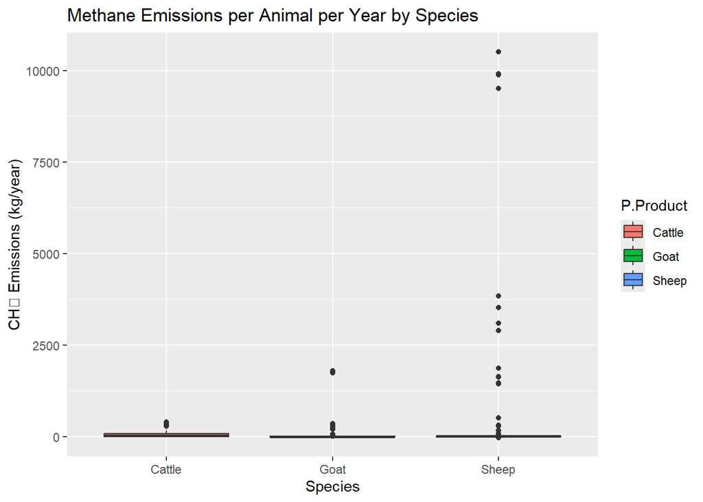

```r
ggplot(GE_combined %>% filter(!is.na(CH4_kg_year)),
       aes(x = P.Product, y = CH4_kg_year, fill = P.Product)) +
  geom_boxplot() +
  labs(
    title = "Methane Emissions per Animal per Year by Species",
    x = "Species", y = "CH₄ Emissions (kg/year)"
  )
```

##16 logical checks

```r
# Assuming your data is stored in a data frame named `feed_intake_data`

# Filter for units that imply kg/day/individual and check if ED.Mean.T > 50
# Identify suspicious feed intake values
suspicious_feed_intake <- feed_intake %>%
  filter(
    # Suspiciously high intake in kg/day/individual
    (
      Out.Unit.Amount %in% c("kg", "kg dm") &
      ED.Mean.T > 50 &
      Out.Unit.Time == "day" &
      Out.Unit.Animals == "individual"
    ) |

    # Suspiciously low intake in g or g dm (regardless of time/animal units)
    (
      Out.Unit.Amount %in% c("g", "g dm") &
      ED.Mean.T >= 1 & ED.Mean.T <= 20
    )
  ) %>%
  select(B.Code, A.Level.Name, ED.Mean.T, Out.Unit.Amount, Out.Unit.Time, Out.Unit.Animals)

# View suspicious entries
print(suspicious_feed_intake)
```

```
## # A tibble: 51 × 6
##    B.Code A.Level.Name  ED.Mean.T Out.Unit.Amount Out.Unit.Time Out.Unit.Animals
##    <chr>  <chr>             <dbl> <chr>           <chr>         <chr>
##  1 BO1095 Treatment Po…      350  kg              day           individual
##  2 EM1017 10MOL              891. kg              day           individual
##  3 EM1017 10MOL             1005. kg              day           individual
##  4 EM1017 10MOL              153. kg              day           individual
##  5 EM1017 20MOL              801. kg              day           individual
##  6 EM1017 20MOL              945. kg              day           individual
##  7 EM1017 20MOL              144. kg              day           individual
##  8 EM1017 30MOL              842. kg              day           individual
##  9 EM1017 30MOL              981. kg              day           individual
## 10 EM1017 30MOL              138. kg              day           individual
## # ℹ 41 more rows
```

Next steps :

- ad libitum data
- all of the variable that we can convert to gross energy digestible energy, metalosiable energy, dihestible energy how many have those by species
- are there ingredients thta are coming again and again